```python
import pandas as pd
import requests
import tweepy
import json
import matplotlib.pyplot as plt
import glob
```

# Gathering

```python
WeRateDogs_archive = pd.read_csv('twitter-archive-enhanced.csv')
WeRateDogs_archive.head(50)
```

|  | tweet_id | in_reply_to_status_id | in_reply_to_user_id | timestamp | source | text | retweeted_status_id | retweeted_status_user_id | retweeted_status_timestamp | expanded_urls | rating_numerator | rating_denominator | name | doggo | floofer | pupper | puppo |
| --- | --- | --- | --- | --- | --- | --- | --- | --- | --- | --- | --- | --- | --- | --- | --- | --- | --- |
| 0 | 892420643555336193 | NaN | NaN | 2017-08-01 16:23:56 +0000 | <a href="http://twitter.com/download/iphone" rel="nofollow">Twitter for iPhone</a> | This is Phineas. He's a mystical boy. Only ever appears in the hole of a donut. 13/10 https://t.co/MgUWQ76dJU | NaN | NaN | NaN | https://twitter.com/dog_rates/status/892420643555336193/photo/1 | 13 | 10 | Phineas | None | None | None | None |
| 1 | 892177421306343426 | NaN | NaN | 2017-08-01 00:17:27 +0000 | <a href="http://twitter.com/download/iphone" rel="nofollow">Twitter for iPhone</a> | This is Tilly. She's just checking pup on you. Hopes you're doing ok. If not, she's available for pats, snugs, boops, the whole bit. 13/10 https://t.co/0Xxu71qeIV | NaN | NaN | NaN | https://twitter.com/dog_rates/status/892177421306343426/photo/1 | 13 | 10 | Tilly | None | None | None | None |
| 2 | 891815181378084864 | NaN | NaN | 2017-07-31 00:18:03 +0000 | <a href="http://twitter.com/download/iphone" rel="nofollow">Twitter for iPhone</a> | This is Archie. He is a rare Norwegian Pouncing Corgo. Lives in the tall grass. You never know when one may strike. 12/10 https://t.co/wUnZnhtVJB | NaN | NaN | NaN | https://twitter.com/dog_rates/status/891815181378084864/photo/1 | 12 | 10 | Archie | None | None | None | None |
| 3 | 891689557279858688 | NaN | NaN | 2017-07-30 15:58:51 +0000 | <a href="http://twitter.com/download/iphone" rel="nofollow">Twitter for iPhone</a> | This is Darla. She commenced a snooze mid meal. 13/10 happens to the best of us https://t.co/tD36da7qLQ | NaN | NaN | NaN | https://twitter.com/dog_rates/status/891689557279858688/photo/1 | 13 | 10 | Darla | None | None | None | None |
| 4 | 891327558926688256 | NaN | NaN | 2017-07-29 16:00:24 +0000 | <a href="http://twitter.com/download/iphone" rel="nofollow">Twitter for iPhone</a> | This is Franklin. He would like you to stop calling him "cute." He is a very fierce shark and should be respected as such. 12/10 #BarkWeek https://t.co/AtUZn91f7f | NaN | NaN | NaN | https://twitter.com/dog_rates/status/891327558926688256/photo/1,https://twitter.com/dog_rates/status/891327558926688256/photo/1 | 12 | 10 | Franklin | None | None | None | None |
| 5 | 891087950875897856 | NaN | NaN | 2017-07-29 00:08:17 +0000 | <a href="http://twitter.com/download/iphone" rel="nofollow">Twitter for iPhone</a> | Here we have a majestic great white breaching off South Africa's coast. Absolutely h*ckin breathtaking. 13/10 (IG: tucker_marlo) #BarkWeek https://t.co/kQ04fDDRmh | NaN | NaN | NaN | https://twitter.com/dog_rates/status/891087950875897856/photo/1 | 13 | 10 | None | None | None | None | None |
| 6 | 890971913173991426 | NaN | NaN | 2017-07-28 16:27:12 +0000 | <a href="http://twitter.com/download/iphone" rel="nofollow">Twitter for iPhone</a> | Meet Jax. He enjoys ice cream so much he gets nervous around it. 13/10 help Jax enjoy more things by clicking below\n\nhttps://t.co/Zr4hWfAs1H https://t.co/tVJBRMnhxl | NaN | NaN | NaN | https://gofundme.com/ydvmve-surgery-for-jax,https://twitter.com/dog_rates/status/890971913173991426/photo/1 | 13 | 10 | Jax | None | None | None | None |
| 7 | 890729181411237888 | NaN | NaN | 2017-07-28 00:22:40 +0000 | <a href="http://twitter.com/download/iphone" rel="nofollow">Twitter for iPhone</a> | When you watch your owner call another dog a good boy but then they turn back to you and say you're a great boy. 13/10 https://t.co/v0nONBcwxq | NaN | NaN | NaN | https://twitter.com/dog_rates/status/890729181411237888/photo/1,https://twitter.com/dog_rates/status/890729181411237888/photo/1 | 13 | 10 | None | None | None | None | None |
| 8 | 890609185150312448 | NaN | NaN | 2017-07-27 16:25:51 +0000 | <a href="http://twitter.com/download/iphone" rel="nofollow">Twitter for iPhone</a> | This is Zoey. She doesn't want to be one of the scary sharks. Just wants to be a snuggly pettable boatpet. 13/10 #BarkWeek https://t.co/9TwLuAGH0b | NaN | NaN | NaN | https://twitter.com/dog_rates/status/890609185150312448/photo/1 | 13 | 10 | Zoey | None | None | None | None |
| 9 | 890240255349198849 | NaN | NaN | 2017-07-26 15:59:51 +0000 | <a href="http://twitter.com/download/iphone" rel="nofollow">Twitter for iPhone</a> | This is Cassie. She is a college pup. Studying international doggo communication and stick theory. 14/10 so elegant much sophisticate https://t.co/t1bfwz5S2A | NaN | NaN | NaN | https://twitter.com/dog_rates/status/890240255349198849/photo/1 | 14 | 10 | Cassie | doggo | None | None | None |
| 10 | 890006608113172480 | NaN | NaN | 2017-07-26 00:31:25 +0000 | <a href="http://twitter.com/download/iphone" rel="nofollow">Twitter for iPhone</a> | This is Koda. He is a South Australian deckshark. Deceptively deadly. Frighteningly majestic. 13/10 would risk a petting #BarkWeek https://t.co/dVPW0B0Mme | NaN | NaN | NaN | https://twitter.com/dog_rates/status/890006608113172480/photo/1,https://twitter.com/dog_rates/status/890006608113172480/photo/1 | 13 | 10 | Koda | None | None | None | None |
| 11 | 889880896479866881 | NaN | NaN | 2017-07-25 16:11:53 +0000 | <a href="http://twitter.com/download/iphone" rel="nofollow">Twitter for iPhone</a> | This is Bruno. He is a service shark. Only gets out of the water to assist you. 13/10 terrifyingly good boy https://t.co/u1XPQMl29g | NaN | NaN | NaN | https://twitter.com/dog_rates/status/889880896479866881/photo/1 | 13 | 10 | Bruno | None | None | None | None |
| 12 | 889665388333682689 | NaN | NaN | 2017-07-25 01:55:32 +0000 | <a href="http://twitter.com/download/iphone" rel="nofollow">Twitter for iPhone</a> | Here's a puppo that seems to be on the fence about something haha no but seriously someone help her. 13/10 https://t.co/BxvuXk0UCm | NaN | NaN | NaN | https://twitter.com/dog_rates/status/889665388333682689/photo/1 | 13 | 10 | None | None | None | None | puppo |
| 13 | 889638837579907072 | NaN | NaN | 2017-07-25 00:10:02 +0000 | <a href="http://twitter.com/download/iphone" rel="nofollow">Twitter for iPhone</a> | This is Ted. He does his best. Sometimes that's not enough. But it's ok. 12/10 would assist https://t.co/f8dEDcrKSR | NaN | NaN | NaN | https://twitter.com/dog_rates/status/889638837579907072/photo/1,https://twitter.com/dog_rates/status/889638837579907072/photo/1 | 12 | 10 | Ted | None | None | None | None |
| 14 | 889531135344209921 | NaN | NaN | 2017-07-24 17:02:04 +0000 | <a href="http://twitter.com/download/iphone" rel="nofollow">Twitter for iPhone</a> | This is Stuart. He's sporting his favorite fanny pack. Secretly filled with bones only. 13/10 puppared puppo #BarkWeek https://t.co/y70o6h3isq | NaN | NaN | NaN | https://twitter.com/dog_rates/status/889531135344209921/photo/1 | 13 | 10 | Stuart | None | None | None | puppo |
| 15 | 889278841981685760 | NaN | NaN | 2017-07-24 00:19:32 +0000 | <a href="http://twitter.com/download/iphone" rel="nofollow">Twitter for iPhone</a> | This is Oliver. You're witnessing one of his many brutal attacks. Seems to be playing with his victim. 13/10 fr*ckin frightening #BarkWeek https://t.co/WpHvrQedPb | NaN | NaN | NaN | https://twitter.com/dog_rates/status/889278841981685760/video/1 | 13 | 10 | Oliver | None | None | None | None |
| 16 | 888917238123831296 | NaN | NaN | 2017-07-23 00:22:39 +0000 | <a href="http://twitter.com/download/iphone" rel="nofollow">Twitter for iPhone</a> | This is Jim. He found a fren. Taught him how to sit like the good boys. 12/10 for both https://t.co/chxruIOUJN | NaN | NaN | NaN | https://twitter.com/dog_rates/status/888917238123831296/photo/1 | 12 | 10 | Jim | None | None | None | None |
| 17 | 888804989199671297 | NaN | NaN | 2017-07-22 16:56:37 +0000 | <a href="http://twitter.com/download/iphone" rel="nofollow">Twitter for iPhone</a> | This is Zeke. He has a new stick. Very proud of it. Would like you to throw it for him without taking it. 13/10 would do my best https://t.co/HTQ77yNQ5K | NaN | NaN | NaN | https://twitter.com/dog_rates/status/888804989199671297/photo/1,https://twitter.com/dog_rates/status/888804989199671297/photo/1 | 13 | 10 | Zeke | None | None | None | None |
| 18 | 888554962724278272 | NaN | NaN | 2017-07-22 00:23:06 +0000 | <a href="http://twitter.com/download/iphone" rel="nofollow">Twitter for iPhone</a> | This is Ralphus. He's powering up. Attempting maximum borkdrive. 13/10 inspirational af https://t.co/YnYAFCTTiK | NaN | NaN | NaN | https://twitter.com/dog_rates/status/888554962724278272/photo/1,https://twitter.com/dog_rates/status/888554962724278272/photo/1,https://twitter.com/dog_rates/status/888554962724278272/photo/1,https://… | 13 | 10 | Ralphus | None | None | None | None |
| 19 | 888202515573088257 | NaN | NaN | 2017-07-21 01:02:36 +0000 | <a href="http://twitter.com/download/iphone" rel="nofollow">Twitter for iPhone</a> | RT @dog_rates: This is Canela. She attempted some fancy porch pics. They were unsuccessful. 13/10 someone help her https://t.co/cLyzpcUcMX | 8.874740e+17 | 4.196984e+09 | 2017-07-19 00:47:34 +0000 | https://twitter.com/dog_rates/status/887473957103951883/photo/1,https://twitter.com/dog_rates/status/887473957103951883/photo/1,https://twitter.com/dog_rates/status/887473957103951883/photo/1,https://… | 13 | 10 | Canela | None | None | None | None |
| 20 | 888078434458587136 | NaN | NaN | 2017-07-20 16:49:33 +0000 | <a href="http://twitter.com/download/iphone" rel="nofollow">Twitter for iPhone</a> | This is Gerald. He was just told he didn't get the job he interviewed for. A h*ckin injustice. 12/10 didn't want the job anyway https://t.co/DK7iDPfuRX | NaN | NaN | NaN | https://twitter.com/dog_rates/status/888078434458587136/photo/1,https://twitter.com/dog_rates/status/888078434458587136/photo/1 | 12 | 10 | Gerald | None | None | None | None |
| 21 | 887705289381826560 | NaN | NaN | 2017-07-19 16:06:48 +0000 | <a href="http://twitter.com/download/iphone" rel="nofollow">Twitter for iPhone</a> | This is Jeffrey. He has a monopoly on the pool noodles. Currently running a 'boop for two' midweek sale. 13/10 h*ckin strategic https://t.co/PhrUk20Q64 | NaN | NaN | NaN | https://twitter.com/dog_rates/status/887705289381826560/photo/1 | 13 | 10 | Jeffrey | None | None | None | None |
| 22 | 887517139158093824 | NaN | NaN | 2017-07-19 03:39:09 +0000 | <a href="http://twitter.com/download/iphone" rel="nofollow">Twitter for iPhone</a> | I've yet to rate a Venezuelan Hover Wiener. This is such an honor. 14/10 paw-inspiring af (IG: roxy.thedoxy) https://t.co/20VrLAA8ba | NaN | NaN | NaN | https://twitter.com/dog_rates/status/887517139158093824/video/1 | 14 | 10 | such | None | None | None | None |
| 23 | 887473957103951883 | NaN | NaN | 2017-07-19 00:47:34 +0000 | <a href="http://twitter.com/download/iphone" rel="nofollow">Twitter for iPhone</a> | This is Canela. She attempted some fancy porch pics. They were unsuccessful. 13/10 someone help her https://t.co/cLyzpcUcMX | NaN | NaN | NaN | https://twitter.com/dog_rates/status/887473957103951883/photo/1,https://twitter.com/dog_rates/status/887473957103951883/photo/1 | 13 | 10 | Canela | None | None | None | None |
| 24 | 887343217045368832 | NaN | NaN | 2017-07-18 16:08:03 +0000 | <a href="http://twitter.com/download/iphone" rel="nofollow">Twitter for iPhone</a> | You may not have known you needed to see this today. 13/10 please enjoy (IG: emmylouroo) https://t.co/WZqNqygEyV | NaN | NaN | NaN | https://twitter.com/dog_rates/status/887343217045368832/video/1 | 13 | 10 | None | None | None | None | None |
| 25 | 887101392804085760 | NaN | NaN | 2017-07-18 00:07:08 +0000 | <a href="http://twitter.com/download/iphone" rel="nofollow">Twitter for iPhone</a> | This... is a Jubilant Antarctic House Bear. We only rate dogs. Please only send dogs. Thank you... 12/10 would suffocate in floof https://t.co/4Ad1jzJSdp | NaN | NaN | NaN | https://twitter.com/dog_rates/status/887101392804085760/photo/1 | 12 | 10 | None | None | None | None | None |
| 26 | 886983233522544640 | NaN | NaN | 2017-07-17 16:17:36 +0000 | <a href="http://twitter.com/download/iphone" rel="nofollow">Twitter for iPhone</a> | This is Maya. She's very shy. Rarely leaves her cup. 13/10 would find her an environment to thrive in https://t.co/I6oNy0CgiT | NaN | NaN | NaN | https://twitter.com/dog_rates/status/886983233522544640/photo/1,https://twitter.com/dog_rates/status/886983233522544640/photo/1 | 13 | 10 | Maya | None | None | None | None |
| 27 | 886736880519319552 | NaN | NaN | 2017-07-16 23:58:41 +0000 | <a href="http://twitter.com/download/iphone" rel="nofollow">Twitter for iPhone</a> | This is Mingus. He's a wonderful father to his smol pup. Confirmed 13/10, but he needs your help\n\nhttps://t.co/bVi0Yr4Cff https://t.co/ISvKOSkd5b | NaN | NaN | NaN | https://www.gofundme.com/mingusneedsus,https://twitter.com/dog_rates/status/886736880519319552/photo/1,https://twitter.com/dog_rates/status/886736880519319552/photo/1 | 13 | 10 | Mingus | None | None | None | None |
| 28 | 886680336477933568 | NaN | NaN | 2017-07-16 20:14:00 +0000 | <a href="http://twitter.com/download/iphone" rel="nofollow">Twitter for iPhone</a> | This is Derek. He's late for a dog meeting. 13/10 pet...al to the metal https://t.co/BCoWue0abA | NaN | NaN | NaN | https://twitter.com/dog_rates/status/886680336477933568/photo/1 | 13 | 10 | Derek | None | None | None | None |
| 29 | 886366144734445568 | NaN | NaN | 2017-07-15 23:25:31 +0000 | <a href="http://twitter.com/download/iphone" rel="nofollow">Twitter for iPhone</a> | This is Roscoe. Another pupper fallen victim to spontaneous tongue ejections. Get the BlepiPen immediate. 12/10 deep breaths Roscoe https://t.co/RGE08MIJox | NaN | NaN | NaN | https://twitter.com/dog_rates/status/886366144734445568/photo/1,https://twitter.com/dog_rates/status/886366144734445568/photo/1 | 12 | 10 | Roscoe | None | None | pupper | None |
| 30 | 886267009285017600 | 8.862664e+17 | 2.281182e+09 | 2017-07-15 16:51:35 +0000 | <a href="http://twitter.com/download/iphone" rel="nofollow">Twitter for iPhone</a> | @NonWhiteHat @MayhewMayhem omg hello tanner you are a scary good boy 12/10 would pet with extreme caution | NaN | NaN | NaN | NaN | 12 | 10 | None | None | None | None | None |
| 31 | 886258384151887873 | NaN | NaN | 2017-07-15 16:17:19 +0000 | <a href="http://twitter.com/download/iphone" rel="nofollow">Twitter for iPhone</a> | This is Waffles. His doggles are pupside down. Unsure how to fix. 13/10 someone assist Waffles https://t.co/xZDA9Qsq1O | NaN | NaN | NaN | https://twitter.com/dog_rates/status/886258384151887873/photo/1 | 13 | 10 | Waffles | None | None | None | None |
| 32 | 886054160059072513 | NaN | NaN | 2017-07-15 02:45:48 +0000 | <a href="http://twitter.com/download/iphone" rel="nofollow">Twitter for iPhone</a> | RT @Athletics: 12/10 #BATP https://t.co/WxwJmvjfxo | 8.860537e+17 | 1.960740e+07 | 2017-07-15 02:44:07 +0000 | https://twitter.com/dog_rates/status/886053434075471873,https://twitter.com/dog_rates/status/886053434075471873 | 12 | 10 | None | None | None | None | None |
| 33 | 885984800019947520 | NaN | NaN | 2017-07-14 22:10:11 +0000 | <a href="http://twitter.com/download/iphone" rel="nofollow">Twitter for iPhone</a> | Viewer discretion advised. This is Jimbo. He will rip ur finger right h*ckin off. Other dog clearly an accessory. 12/10 pls pet with caution https://t.co/BuveP0uMF1 | NaN | NaN | NaN | https://twitter.com/dog_rates/status/885984800019947520/photo/1 | 12 | 10 | Jimbo | None | None | None | None |
| 34 | 885528943205470208 | NaN | NaN | 2017-07-13 15:58:47 +0000 | <a href="http://twitter.com/download/iphone" rel="nofollow">Twitter for iPhone</a> | This is Maisey. She fell asleep mid-excavation. Happens to the best of us. 13/10 would pat noggin approvingly https://t.co/tp1kQ8i9JF | NaN | NaN | NaN | https://twitter.com/dog_rates/status/885528943205470208/photo/1 | 13 | 10 | Maisey | None | None | None | None |
| 35 | 885518971528720385 | NaN | NaN | 2017-07-13 15:19:09 +0000 | <a href="http://twitter.com/download/iphone" rel="nofollow">Twitter for iPhone</a> | I have a new hero and his name is Howard. 14/10 https://t.co/gzLHboL7Sk | NaN | NaN | NaN | https://twitter.com/4bonds2carbon/status/885517367337512960 | 14 | 10 | None | None | None | None | None |
| 36 | 885311592912609280 | NaN | NaN | 2017-07-13 01:35:06 +0000 | <a href="http://twitter.com/download/iphone" rel="nofollow">Twitter for iPhone</a> | RT @dog_rates: This is Lilly. She just parallel barked. Kindly requests a reward now. 13/10 would pet so well https://t.co/SATN4If5H5 | 8.305833e+17 | 4.196984e+09 | 2017-02-12 01:04:29 +0000 | https://twitter.com/dog_rates/status/830583320585068544/photo/1,https://twitter.com/dog_rates/status/830583320585068544/photo/1,https://twitter.com/dog_rates/status/830583320585068544/photo/1,https://… | 13 | 10 | Lilly | None | None | None | None |
| 37 | 885167619883638784 | NaN | NaN | 2017-07-12 16:03:00 +0000 | <a href="http://twitter.com/download/iphone" rel="nofollow">Twitter for iPhone</a> | Here we have a corgi undercover as a malamute. Pawbably doing important investigative work. Zero control over tongue happenings. 13/10 https://t.co/44ItaMubBf | NaN | NaN | NaN | https://twitter.com/dog_rates/status/885167619883638784/photo/1,https://twitter.com/dog_rates/status/885167619883638784/photo/1,https://twitter.com/dog_rates/status/885167619883638784/photo/1,https://… | 13 | 10 | None | None | None | None | None |
| 38 | 884925521741709313 | NaN | NaN | 2017-07-12 00:01:00 +0000 | <a href="http://twitter.com/download/iphone" rel="nofollow">Twitter for iPhone</a> | This is Earl. He found a hat. Nervous about what you think of it. 12/10 it's delightful, Earl https://t.co/MYJvdlNRVa | NaN | NaN | NaN | https://twitter.com/dog_rates/status/884925521741709313/photo/1 | 12 | 10 | Earl | None | None | None | None |
| 39 | 884876753390489601 | NaN | NaN | 2017-07-11 20:47:12 +0000 | <a href="http://twitter.com/download/iphone" rel="nofollow">Twitter for iPhone</a> | This is Lola. It's her first time outside. Must test the earth and taste the atmosphere. 13/10 you're doing great Lola https://t.co/74TKAUsLkO | NaN | NaN | NaN | https://twitter.com/dog_rates/status/884876753390489601/photo/1,https://twitter.com/dog_rates/status/884876753390489601/photo/1,https://twitter.com/dog_rates/status/884876753390489601/photo/1,https://… | 13 | 10 | Lola | None | None | None | None |
| 40 | 884562892145688576 | NaN | NaN | 2017-07-11 00:00:02 +0000 | <a href="http://twitter.com/download/iphone" rel="nofollow">Twitter for iPhone</a> | This is Kevin. He's just so happy. 13/10 what is your secret Kevin https://t.co/1r4MFCbCX5 | NaN | NaN | NaN | https://twitter.com/dog_rates/status/884562892145688576/photo/1 | 13 | 10 | Kevin | None | None | None | None |
| 41 | 884441805382717440 | NaN | NaN | 2017-07-10 15:58:53 +0000 | <a href="http://twitter.com/download/iphone" rel="nofollow">Twitter for iPhone</a> | I present to you, Pup in Hat. Pup in Hat is great for all occasions. Extremely versatile. Compact as h*ck. 14/10 (IG: itselizabethgales) https://t.co/vvBOcC2VdC | NaN | NaN | NaN | https://twitter.com/dog_rates/status/884441805382717440/photo/1 | 14 | 10 | None | None | None | None | None |
| 42 | 884247878851493888 | NaN | NaN | 2017-07-10 03:08:17 +0000 | <a href="http://twitter.com/download/iphone" rel="nofollow">Twitter for iPhone</a> | OMG HE DIDN'T MEAN TO HE WAS JUST TRYING A LITTLE BARKOUR HE'S SUPER SORRY 13/10 WOULD FORGIVE IMMEDIATE https://t.co/uF3pQ8Wubj | NaN | NaN | NaN | https://twitter.com/kaijohnson_19/status/883965650754039809 | 13 | 10 | None | None | None | None | None |
| 43 | 884162670584377345 | NaN | NaN | 2017-07-09 21:29:42 +0000 | <a href="http://twitter.com/download/iphone" rel="nofollow">Twitter for iPhone</a> | Meet Yogi. He doesn't have any important dog meetings today he just enjoys looking his best at all times. 12/10 for dangerously dapper doggo https://t.co/YSI00BzTBZ | NaN | NaN | NaN | https://twitter.com/dog_rates/status/884162670584377345/photo/1 | 12 | 10 | Yogi | doggo | None | None | None |
| 44 | 883838122936631299 | NaN | NaN | 2017-07-09 00:00:04 +0000 | <a href="http://twitter.com/download/iphone" rel="nofollow">Twitter for iPhone</a> | This is Noah. He can't believe someone made this mess. Got the vacuum out for you though. Offered to help clean pup. 12/10 super good boy https://t.co/V85xujjDDY | NaN | NaN | NaN | https://twitter.com/dog_rates/status/883838122936631299/photo/1 | 12 | 10 | Noah | None | None | None | None |
| 45 | 883482846933004288 | NaN | NaN | 2017-07-08 00:28:19 +0000 | <a href="http://twitter.com/download/iphone" rel="nofollow">Twitter for iPhone</a> | This is Bella. She hopes her smile made you smile. If not, she is also offering you her favorite monkey. 13.5/10 https://t.co/qjrljjt948 | NaN | NaN | NaN | https://twitter.com/dog_rates/status/883482846933004288/photo/1,https://twitter.com/dog_rates/status/883482846933004288/photo/1 | 5 | 10 | Bella | None | None | None | None |
| 46 | 883360690899218434 | NaN | NaN | 2017-07-07 16:22:55 +0000 | <a href="http://twitter.com/download/iphone" rel="nofollow">Twitter for iPhone</a> | Meet Grizzwald. He may be the floofiest floofer I ever did see. Lost eyes saving a schoolbus from a volcano erpuption. 13/10 heroic as h*ck https://t.co/rf661IFEYP | NaN | NaN | NaN | https://twitter.com/dog_rates/status/883360690899218434/photo/1 | 13 | 10 | Grizzwald | None | floofer | None | None |
| 47 | 883117836046086144 | NaN | NaN | 2017-07-07 00:17:54 +0000 | <a href="http://twitter.com/download/iphone" rel="nofollow">Twitter for iPhone</a> | Please only send dogs. We don't rate mechanics, no matter how h*ckin good. Thank you... 13/10 would sneak a pat https://t.co/Se5fZ9wp5E | NaN | NaN | NaN | https://twitter.com/dog_rates/status/883117836046086144/photo/1,https://twitter.com/dog_rates/status/883117836046086144/photo/1 | 13 | 10 | None | None | None | None | None |
| 48 | 882992080364220416 | NaN | NaN | 2017-07-06 15:58:11 +0000 | <a href="http://twitter.com/download/iphone" rel="nofollow">Twitter for iPhone</a> | This is Rusty. He wasn't ready for the first pic. Clearly puppared for the second. 13/10 confirmed great boy https://t.co/tyER0KpdXj | NaN | NaN | NaN | https://twitter.com/dog_rates/status/882992080364220416/photo/1,https://twitter.com/dog_rates/status/882992080364220416/photo/1 | 13 | 10 | Rusty | None | None | None | None |
| 49 | 882762694511734784 | NaN | NaN | 2017-07-06 00:46:41 +0000 | <a href="http://twitter.com/download/iphone" rel="nofollow">Twitter for iPhone</a> | This is Gus. He's quite the cheeky pupper. Already perfected the disinterested wink. 12/10 would let steal my girl https://t.co/D43I96SlVu | NaN | NaN | NaN | https://twitter.com/dog_rates/status/882762694511734784/photo/1 | 12 | 10 | Gus | None | None | pupper | None |

We have 2356 entries in WeRateDogs Archive. 17 columns are provided as part of the dataset.

```python
WeRateDogs_archive.info()
```

```
<class 'pandas.core.frame.DataFrame'>
RangeIndex: 2356 entries, 0 to 2355
Data columns (total 17 columns):
tweet_id                      2356 non-null int64
in_reply_to_status_id         78 non-null float64
in_reply_to_user_id           78 non-null float64
timestamp                     2356 non-null object
source                        2356 non-null object
text                          2356 non-null object
retweeted_status_id           181 non-null float64
retweeted_status_user_id      181 non-null float64
retweeted_status_timestamp    181 non-null object
expanded_urls                 2297 non-null object
rating_numerator              2356 non-null int64
rating_denominator            2356 non-null int64
name                          2356 non-null object
doggo                         2356 non-null object
floofer                       2356 non-null object
pupper                        2356 non-null object
puppo                         2356 non-null object
dtypes: float64(4), int64(3), object(10)
memory usage: 313.0+ KB
```

```python
url=" https://d17h27t6h515a5.cloudfront.net/topher/2017/August/599fd2ad_image-predictions/image-predictions.tsv"
response = requests.get(url)

with open('image_predictions.tsv', 'wb') as file:
    file.write(response.content)

image_predictions = pd.read_csv('image_predictions.tsv', sep='\t')

image_predictions.head()
```

|  | tweet_id | jpg_url | img_num | p1 | p1_conf | p1_dog | p2 | p2_conf | p2_dog | p3 | p3_conf | p3_dog |
| --- | --- | --- | --- | --- | --- | --- | --- | --- | --- | --- | --- | --- |
| 0 | 666020888022790149 | https://pbs.twimg.com/media/CT4udn0WwAA0aMy.jpg | 1 | Welsh_springer_spaniel | 0.465074 | True | collie | 0.156665 | True | Shetland_sheepdog | 0.061428 | True |
| 1 | 666029285002620928 | https://pbs.twimg.com/media/CT42GRgUYAA5iDo.jpg | 1 | redbone | 0.506826 | True | miniature_pinscher | 0.074192 | True | Rhodesian_ridgeback | 0.072010 | True |
| 2 | 666033412701032449 | https://pbs.twimg.com/media/CT4521TWwAEvMyu.jpg | 1 | German_shepherd | 0.596461 | True | malinois | 0.138584 | True | bloodhound | 0.116197 | True |
| 3 | 666044226329800704 | https://pbs.twimg.com/media/CT5Dr8HUEAA-lEu.jpg | 1 | Rhodesian_ridgeback | 0.408143 | True | redbone | 0.360687 | True | miniature_pinscher | 0.222752 | True |
| 4 | 666049248165822465 | https://pbs.twimg.com/media/CT5IQmsXIAAKY4A.jpg | 1 | miniature_pinscher | 0.560311 | True | Rottweiler | 0.243682 | True | Doberman | 0.154629 | True |

```python
# Reading tweet-json.txt file, line by line and append it to "status" list
with open('tweet-json.txt') as file:
    status = []
    for line in file:
        status.append(json.loads(line))

#using json_normalize to convert json keys to columns
from pandas.io.json import json_normalize
df_json = pd.DataFrame.from_dict(json_normalize(status), orient='columns')

# Refining the the json dataframe to the columns we need for analysis
columns_needed = ['id' , 'retweet_count' , 'favorite_count']
df_json_cleaned = df_json[columns_needed]



df_json_cleaned.rename(columns = {'id':'tweet_id'} , inplace=True)

df_json_cleaned.head()
```

|  | tweet_id | retweet_count | favorite_count |
| --- | --- | --- | --- |
| 0 | 892420643555336193 | 8853 | 39467 |
| 1 | 892177421306343426 | 6514 | 33819 |
| 2 | 891815181378084864 | 4328 | 25461 |
| 3 | 891689557279858688 | 8964 | 42908 |
| 4 | 891327558926688256 | 9774 | 41048 |

# Assessing

```python
WeRateDogs_archive.info()
```

```
<class 'pandas.core.frame.DataFrame'>
RangeIndex: 2356 entries, 0 to 2355
Data columns (total 17 columns):
tweet_id                      2356 non-null int64
in_reply_to_status_id         78 non-null float64
in_reply_to_user_id           78 non-null float64
timestamp                     2356 non-null object
source                        2356 non-null object
text                          2356 non-null object
retweeted_status_id           181 non-null float64
retweeted_status_user_id      181 non-null float64
retweeted_status_timestamp    181 non-null object
expanded_urls                 2297 non-null object
rating_numerator              2356 non-null int64
rating_denominator            2356 non-null int64
name                          2356 non-null object
doggo                         2356 non-null object
floofer                       2356 non-null object
pupper                        2356 non-null object
puppo                         2356 non-null object
dtypes: float64(4), int64(3), object(10)
memory usage: 313.0+ KB
```

```python
WeRateDogs_archive.tweet_id.nunique()
print("All IDs are unique")
```

```
All IDs are unique
```

```python
print (WeRateDogs_archive.source.value_counts())
print("\n No twiiter for Android ?!! Weird Hah :) ")
```

```
<a href="http://twitter.com/download/iphone" rel="nofollow">Twitter for iPhone</a>     2221
<a href="http://vine.co" rel="nofollow">Vine - Make a Scene</a>                        91
<a href="http://twitter.com" rel="nofollow">Twitter Web Client</a>                     33
<a href="https://about.twitter.com/products/tweetdeck" rel="nofollow">TweetDeck</a>    11
Name: source, dtype: int64

 No twiiter for Android ?!! Weird Hah :)
```

```python
#This is to see full text and assessing the data deeply ;)
pd.set_option('display.max_colwidth', -1)

#Here we want to see if there is another way of calling a dog name other than "This is"
WeRateDogs_archive[~WeRateDogs_archive['text'].str.contains("This is" , case=False)]
```

|  | tweet_id | in_reply_to_status_id | in_reply_to_user_id | timestamp | source | text | retweeted_status_id | retweeted_status_user_id | retweeted_status_timestamp | expanded_urls | rating_numerator | rating_denominator | name | doggo | floofer | pupper | puppo |
| --- | --- | --- | --- | --- | --- | --- | --- | --- | --- | --- | --- | --- | --- | --- | --- | --- | --- |
| 5 | 891087950875897856 | NaN | NaN | 2017-07-29 00:08:17 +0000 | <a href="http://twitter.com/download/iphone" rel="nofollow">Twitter for iPhone</a> | Here we have a majestic great white breaching off South Africa's coast. Absolutely h*ckin breathtaking. 13/10 (IG: tucker_marlo) #BarkWeek https://t.co/kQ04fDDRmh | NaN | NaN | NaN | https://twitter.com/dog_rates/status/891087950875897856/photo/1 | 13 | 10 | None | None | None | None | None |
| 6 | 890971913173991426 | NaN | NaN | 2017-07-28 16:27:12 +0000 | <a href="http://twitter.com/download/iphone" rel="nofollow">Twitter for iPhone</a> | Meet Jax. He enjoys ice cream so much he gets nervous around it. 13/10 help Jax enjoy more things by clicking below\n\nhttps://t.co/Zr4hWfAs1H https://t.co/tVJBRMnhxl | NaN | NaN | NaN | https://gofundme.com/ydvmve-surgery-for-jax,https://twitter.com/dog_rates/status/890971913173991426/photo/1 | 13 | 10 | Jax | None | None | None | None |
| 7 | 890729181411237888 | NaN | NaN | 2017-07-28 00:22:40 +0000 | <a href="http://twitter.com/download/iphone" rel="nofollow">Twitter for iPhone</a> | When you watch your owner call another dog a good boy but then they turn back to you and say you're a great boy. 13/10 https://t.co/v0nONBcwxq | NaN | NaN | NaN | https://twitter.com/dog_rates/status/890729181411237888/photo/1,https://twitter.com/dog_rates/status/890729181411237888/photo/1 | 13 | 10 | None | None | None | None | None |
| 12 | 889665388333682689 | NaN | NaN | 2017-07-25 01:55:32 +0000 | <a href="http://twitter.com/download/iphone" rel="nofollow">Twitter for iPhone</a> | Here's a puppo that seems to be on the fence about something haha no but seriously someone help her. 13/10 https://t.co/BxvuXk0UCm | NaN | NaN | NaN | https://twitter.com/dog_rates/status/889665388333682689/photo/1 | 13 | 10 | None | None | None | None | puppo |
| 24 | 887343217045368832 | NaN | NaN | 2017-07-18 16:08:03 +0000 | <a href="http://twitter.com/download/iphone" rel="nofollow">Twitter for iPhone</a> | You may not have known you needed to see this today. 13/10 please enjoy (IG: emmylouroo) https://t.co/WZqNqygEyV | NaN | NaN | NaN | https://twitter.com/dog_rates/status/887343217045368832/video/1 | 13 | 10 | None | None | None | None | None |
| 25 | 887101392804085760 | NaN | NaN | 2017-07-18 00:07:08 +0000 | <a href="http://twitter.com/download/iphone" rel="nofollow">Twitter for iPhone</a> | This... is a Jubilant Antarctic House Bear. We only rate dogs. Please only send dogs. Thank you... 12/10 would suffocate in floof https://t.co/4Ad1jzJSdp | NaN | NaN | NaN | https://twitter.com/dog_rates/status/887101392804085760/photo/1 | 12 | 10 | None | None | None | None | None |
| 30 | 886267009285017600 | 8.862664e+17 | 2.281182e+09 | 2017-07-15 16:51:35 +0000 | <a href="http://twitter.com/download/iphone" rel="nofollow">Twitter for iPhone</a> | @NonWhiteHat @MayhewMayhem omg hello tanner you are a scary good boy 12/10 would pet with extreme caution | NaN | NaN | NaN | NaN | 12 | 10 | None | None | None | None | None |
| 32 | 886054160059072513 | NaN | NaN | 2017-07-15 02:45:48 +0000 | <a href="http://twitter.com/download/iphone" rel="nofollow">Twitter for iPhone</a> | RT @Athletics: 12/10 #BATP https://t.co/WxwJmvjfxo | 8.860537e+17 | 1.960740e+07 | 2017-07-15 02:44:07 +0000 | https://twitter.com/dog_rates/status/886053434075471873,https://twitter.com/dog_rates/status/886053434075471873 | 12 | 10 | None | None | None | None | None |
| 35 | 885518971528720385 | NaN | NaN | 2017-07-13 15:19:09 +0000 | <a href="http://twitter.com/download/iphone" rel="nofollow">Twitter for iPhone</a> | I have a new hero and his name is Howard. 14/10 https://t.co/gzLHboL7Sk | NaN | NaN | NaN | https://twitter.com/4bonds2carbon/status/885517367337512960 | 14 | 10 | None | None | None | None | None |
| 37 | 885167619883638784 | NaN | NaN | 2017-07-12 16:03:00 +0000 | <a href="http://twitter.com/download/iphone" rel="nofollow">Twitter for iPhone</a> | Here we have a corgi undercover as a malamute. Pawbably doing important investigative work. Zero control over tongue happenings. 13/10 https://t.co/44ItaMubBf | NaN | NaN | NaN | https://twitter.com/dog_rates/status/885167619883638784/photo/1,https://twitter.com/dog_rates/status/885167619883638784/photo/1,https://twitter.com/dog_rates/status/885167619883638784/photo/1,https://… | 13 | 10 | None | None | None | None | None |
| 41 | 884441805382717440 | NaN | NaN | 2017-07-10 15:58:53 +0000 | <a href="http://twitter.com/download/iphone" rel="nofollow">Twitter for iPhone</a> | I present to you, Pup in Hat. Pup in Hat is great for all occasions. Extremely versatile. Compact as h*ck. 14/10 (IG: itselizabethgales) https://t.co/vvBOcC2VdC | NaN | NaN | NaN | https://twitter.com/dog_rates/status/884441805382717440/photo/1 | 14 | 10 | None | None | None | None | None |
| 42 | 884247878851493888 | NaN | NaN | 2017-07-10 03:08:17 +0000 | <a href="http://twitter.com/download/iphone" rel="nofollow">Twitter for iPhone</a> | OMG HE DIDN'T MEAN TO HE WAS JUST TRYING A LITTLE BARKOUR HE'S SUPER SORRY 13/10 WOULD FORGIVE IMMEDIATE https://t.co/uF3pQ8Wubj | NaN | NaN | NaN | https://twitter.com/kaijohnson_19/status/883965650754039809 | 13 | 10 | None | None | None | None | None |
| 43 | 884162670584377345 | NaN | NaN | 2017-07-09 21:29:42 +0000 | <a href="http://twitter.com/download/iphone" rel="nofollow">Twitter for iPhone</a> | Meet Yogi. He doesn't have any important dog meetings today he just enjoys looking his best at all times. 12/10 for dangerously dapper doggo https://t.co/YSI00BzTBZ | NaN | NaN | NaN | https://twitter.com/dog_rates/status/884162670584377345/photo/1 | 12 | 10 | Yogi | doggo | None | None | None |
| 46 | 883360690899218434 | NaN | NaN | 2017-07-07 16:22:55 +0000 | <a href="http://twitter.com/download/iphone" rel="nofollow">Twitter for iPhone</a> | Meet Grizzwald. He may be the floofiest floofer I ever did see. Lost eyes saving a schoolbus from a volcano erpuption. 13/10 heroic as h*ck https://t.co/rf661IFEYP | NaN | NaN | NaN | https://twitter.com/dog_rates/status/883360690899218434/photo/1 | 13 | 10 | Grizzwald | None | floofer | None | None |
| 47 | 883117836046086144 | NaN | NaN | 2017-07-07 00:17:54 +0000 | <a href="http://twitter.com/download/iphone" rel="nofollow">Twitter for iPhone</a> | Please only send dogs. We don't rate mechanics, no matter how h*ckin good. Thank you... 13/10 would sneak a pat https://t.co/Se5fZ9wp5E | NaN | NaN | NaN | https://twitter.com/dog_rates/status/883117836046086144/photo/1,https://twitter.com/dog_rates/status/883117836046086144/photo/1 | 13 | 10 | None | None | None | None | None |
| 55 | 881633300179243008 | 8.816070e+17 | 4.738443e+07 | 2017-07-02 21:58:53 +0000 | <a href="http://twitter.com/download/iphone" rel="nofollow">Twitter for iPhone</a> | @roushfenway These are good dogs but 17/10 is an emotional impulse rating. More like 13/10s | NaN | NaN | NaN | NaN | 17 | 10 | None | None | None | None | None |
| 56 | 881536004380872706 | NaN | NaN | 2017-07-02 15:32:16 +0000 | <a href="http://twitter.com/download/iphone" rel="nofollow">Twitter for iPhone</a> | Here is a pupper approaching maximum borkdrive. Zooming at never before seen speeds. 14/10 paw-inspiring af \n(IG: puffie_the_chow) https://t.co/ghXBIIeQZF | NaN | NaN | NaN | https://twitter.com/dog_rates/status/881536004380872706/video/1 | 14 | 10 | a | None | None | pupper | None |
| 57 | 881268444196462592 | NaN | NaN | 2017-07-01 21:49:04 +0000 | <a href="http://twitter.com/download/iphone" rel="nofollow">Twitter for iPhone</a> | Meet Elliot. He's a Canadian Forrest Pup. Unusual number of antlers for a dog. Sneaky tongue slip to celebrate #Canada150. 12/10 would pet https://t.co/cgwJwowTMC | NaN | NaN | NaN | https://twitter.com/dog_rates/status/881268444196462592/photo/1 | 12 | 10 | Elliot | None | None | None | None |
| 59 | 880872448815771648 | NaN | NaN | 2017-06-30 19:35:32 +0000 | <a href="http://twitter.com/download/iphone" rel="nofollow">Twitter for iPhone</a> | Ugh not again. We only rate dogs. Please don't send in well-dressed floppy-tongued street penguins. Dogs only please. Thank you... 12/10 https://t.co/WiAMbTkDPf | NaN | NaN | NaN | https://twitter.com/dog_rates/status/880872448815771648/photo/1 | 12 | 10 | None | None | None | None | None |
| 61 | 880221127280381952 | NaN | NaN | 2017-06-29 00:27:25 +0000 | <a href="http://twitter.com/download/iphone" rel="nofollow">Twitter for iPhone</a> | Meet Jesse. He's a Fetty Woof. His tongue ejects without warning. A true bleptomaniac. 12/10 would snug well https://t.co/fUod0tVmvK | NaN | NaN | NaN | https://twitter.com/dog_rates/status/880221127280381952/photo/1,https://twitter.com/dog_rates/status/880221127280381952/photo/1 | 12 | 10 | Jesse | None | None | None | None |
| 62 | 880095782870896641 | NaN | NaN | 2017-06-28 16:09:20 +0000 | <a href="http://twitter.com/download/iphone" rel="nofollow">Twitter for iPhone</a> | Please don't send in photos without dogs in them. We're not @porch_rates. Insubordinate and churlish. Pretty good porch tho 11/10 https://t.co/HauE8M3Bu4 | NaN | NaN | NaN | https://twitter.com/dog_rates/status/880095782870896641/photo/1 | 11 | 10 | None | None | None | None | None |
| 64 | 879674319642796034 | 8.795538e+17 | 3.105441e+09 | 2017-06-27 12:14:36 +0000 | <a href="http://twitter.com/download/iphone" rel="nofollow">Twitter for iPhone</a> | @RealKentMurphy 14/10 confirmed | NaN | NaN | NaN | NaN | 14 | 10 | None | None | None | None | None |
| 72 | 878604707211726852 | NaN | NaN | 2017-06-24 13:24:20 +0000 | <a href="http://twitter.com/download/iphone" rel="nofollow">Twitter for iPhone</a> | Martha is stunning how h*ckin dare you. 13/10 https://t.co/9uABQXgjwa | NaN | NaN | NaN | https://twitter.com/bbcworld/status/878599868507402241 | 13 | 10 | None | None | None | None | None |
| 73 | 878404777348136964 | NaN | NaN | 2017-06-24 00:09:53 +0000 | <a href="http://twitter.com/download/iphone" rel="nofollow">Twitter for iPhone</a> | RT @dog_rates: Meet Shadow. In an attempt to reach maximum zooming borkdrive, he tore his ACL. Still 13/10 tho. Help him out below\n\nhttps:/… | 8.782815e+17 | 4.196984e+09 | 2017-06-23 16:00:04 +0000 | https://www.gofundme.com/3yd6y1c,https://twitter.com/dog_rates/status/878281511006478336/photo/1 | 13 | 10 | Shadow | None | None | None | None |
| 74 | 878316110768087041 | NaN | NaN | 2017-06-23 18:17:33 +0000 | <a href="http://twitter.com/download/iphone" rel="nofollow">Twitter for iPhone</a> | RT @dog_rates: Meet Terrance. He's being yelled at because he stapled the wrong stuff together. 11/10 hang in there Terrance https://t.co/i… | 6.690004e+17 | 4.196984e+09 | 2015-11-24 03:51:38 +0000 | https://twitter.com/dog_rates/status/669000397445533696/photo/1 | 11 | 10 | Terrance | None | None | None | None |
| 75 | 878281511006478336 | NaN | NaN | 2017-06-23 16:00:04 +0000 | <a href="http://twitter.com/download/iphone" rel="nofollow">Twitter for iPhone</a> | Meet Shadow. In an attempt to reach maximum zooming borkdrive, he tore his ACL. Still 13/10 tho. Help him out below\n\nhttps://t.co/245xJJElsY https://t.co/lUiQH219v6 | NaN | NaN | NaN | https://www.gofundme.com/3yd6y1c,https://twitter.com/dog_rates/status/878281511006478336/photo/1 | 13 | 10 | Shadow | None | None | None | None |
| 78 | 877611172832227328 | NaN | NaN | 2017-06-21 19:36:23 +0000 | <a href="http://twitter.com/download/iphone" rel="nofollow">Twitter for iPhone</a> | RT @rachel2195: @dog_rates the boyfriend and his soaking wet pupper h*cking love his new hat 14/10 https://t.co/dJx4Gzc50G | 8.768508e+17 | 5.128045e+08 | 2017-06-19 17:14:49 +0000 | https://twitter.com/rachel2195/status/876850772322988033/photo/1,https://twitter.com/rachel2195/status/876850772322988033/photo/1,https://twitter.com/rachel2195/status/876850772322988033/photo/1,https… | 14 | 10 | None | None | None | pupper | None |
| 80 | 877316821321428993 | NaN | NaN | 2017-06-21 00:06:44 +0000 | <a href="http://twitter.com/download/iphone" rel="nofollow">Twitter for iPhone</a> | Meet Dante. At first he wasn't a fan of his new raincoat, then he saw his reflection. H*ckin handsome. 13/10 for water resistant good boy https://t.co/SHRTIo5pxc | NaN | NaN | NaN | https://twitter.com/dog_rates/status/877316821321428993/photo/1,https://twitter.com/dog_rates/status/877316821321428993/photo/1 | 13 | 10 | Dante | None | None | None | None |
| 83 | 876537666061221889 | NaN | NaN | 2017-06-18 20:30:39 +0000 | <a href="http://twitter.com/download/iphone" rel="nofollow">Twitter for iPhone</a> | I can say with the pupmost confidence that the doggos who assisted with this search are heroic as h*ck. 14/10 for all https://t.co/8yoc1CNTsu | NaN | NaN | NaN | https://twitter.com/mpstowerham/status/876162994446753793 | 14 | 10 | None | None | None | None | None |
| 85 | 876120275196170240 | NaN | NaN | 2017-06-17 16:52:05 +0000 | <a href="http://twitter.com/download/iphone" rel="nofollow">Twitter for iPhone</a> | Meet Venti, a seemingly caffeinated puppoccino. She was just informed the weekend would include walks, pats and scritches. 13/10 much excite https://t.co/ejExJFq3ek | NaN | NaN | NaN | https://twitter.com/dog_rates/status/876120275196170240/photo/1 | 13 | 10 | Venti | None | None | None | None |
| ... | ... | ... | ... | ... | ... | ... | ... | ... | ... | ... | ... | ... | ... | ... | ... | ... | ... |
| 2301 | 667044094246576128 | NaN | NaN | 2015-11-18 18:17:59 +0000 | <a href="http://twitter.com/download/iphone" rel="nofollow">Twitter for iPhone</a> | 12/10 gimme now https://t.co/QZAnwgnOMB | NaN | NaN | NaN | https://twitter.com/dog_rates/status/667044094246576128/photo/1 | 12 | 10 | None | None | None | None | None |
| 2305 | 666837028449972224 | NaN | NaN | 2015-11-18 04:35:11 +0000 | <a href="http://twitter.com/download/iphone" rel="nofollow">Twitter for iPhone</a> | My goodness. Very rare dog here. Large. Tail dangerous. Kinda fat. Only eats leaves. Doesn't come when called 3/10 https://t.co/xYGdBrMS9h | NaN | NaN | NaN | https://twitter.com/dog_rates/status/666837028449972224/photo/1 | 3 | 10 | None | None | None | None | None |
| 2306 | 666835007768551424 | NaN | NaN | 2015-11-18 04:27:09 +0000 | <a href="http://twitter.com/download/iphone" rel="nofollow">Twitter for iPhone</a> | These are Peruvian Feldspars. Their names are Cupit and Prencer. Both resemble Rand Paul. Sick outfits 10/10 &amp; 10/10 https://t.co/ZnEMHBsAs1 | NaN | NaN | NaN | https://twitter.com/dog_rates/status/666835007768551424/photo/1 | 10 | 10 | None | None | None | None | None |
| 2307 | 666826780179869698 | NaN | NaN | 2015-11-18 03:54:28 +0000 | <a href="http://twitter.com/download/iphone" rel="nofollow">Twitter for iPhone</a> | 12/10 simply brilliant pup https://t.co/V6ZzG45zzG | NaN | NaN | NaN | https://twitter.com/dog_rates/status/666826780179869698/photo/1 | 12 | 10 | None | None | None | None | None |
| 2310 | 666786068205871104 | NaN | NaN | 2015-11-18 01:12:41 +0000 | <a href="http://twitter.com/download/iphone" rel="nofollow">Twitter for iPhone</a> | Unfamiliar with this breed. Ears pointy af. Won't let go of seashell. Won't eat kibble. Not very fast. Bad dog 2/10 https://t.co/EIn5kElY1S | NaN | NaN | NaN | https://twitter.com/dog_rates/status/666786068205871104/photo/1 | 2 | 10 | None | None | None | None | None |
| 2316 | 666649482315059201 | NaN | NaN | 2015-11-17 16:09:56 +0000 | <a href="http://twitter.com/download/iphone" rel="nofollow">Twitter for iPhone</a> | Cool dog. Enjoys couch. Low monotone bark. Very nice kicks. Pisses milk (must be rare). Can't go down stairs. 4/10 https://t.co/vXMKrJC81s | NaN | NaN | NaN | https://twitter.com/dog_rates/status/666649482315059201/photo/1 | 4 | 10 | None | None | None | None | None |
| 2320 | 666437273139982337 | NaN | NaN | 2015-11-17 02:06:42 +0000 | <a href="http://twitter.com/download/iphone" rel="nofollow">Twitter for iPhone</a> | Here we see a lone northeastern Cumberbatch. Half ladybug. Only builds with bricks. Very confident with body. 7/10 https://t.co/7LtjBS0GPK | NaN | NaN | NaN | https://twitter.com/dog_rates/status/666437273139982337/photo/1 | 7 | 10 | None | None | None | None | None |
| 2321 | 666435652385423360 | NaN | NaN | 2015-11-17 02:00:15 +0000 | <a href="http://twitter.com/download/iphone" rel="nofollow">Twitter for iPhone</a> | "Can you behave? You're ruining my wedding day"\nDOG: idgaf this flashlight tastes good as hell\n\n10/10 https://t.co/GlFZPzqcEU | NaN | NaN | NaN | https://twitter.com/dog_rates/status/666435652385423360/photo/1 | 10 | 10 | None | None | None | None | None |
| 2322 | 666430724426358785 | NaN | NaN | 2015-11-17 01:40:41 +0000 | <a href="http://twitter.com/download/iphone" rel="nofollow">Twitter for iPhone</a> | Oh boy what a pup! Sunglasses take this one to the next level. Weirdly folds front legs. Pretty big. 6/10 https://t.co/yECbFrSArM | NaN | NaN | NaN | https://twitter.com/dog_rates/status/666430724426358785/photo/1 | 6 | 10 | None | None | None | None | None |
| 2323 | 666428276349472768 | NaN | NaN | 2015-11-17 01:30:57 +0000 | <a href="http://twitter.com/download/iphone" rel="nofollow">Twitter for iPhone</a> | Here we have an Austrian Pulitzer. Collectors edition. Levitates (?). 7/10 would garden with https://t.co/NMQq6HIglK | NaN | NaN | NaN | https://twitter.com/dog_rates/status/666428276349472768/photo/1 | 7 | 10 | None | None | None | None | None |
| 2324 | 666421158376562688 | NaN | NaN | 2015-11-17 01:02:40 +0000 | <a href="http://twitter.com/download/iphone" rel="nofollow">Twitter for iPhone</a> | *internally screaming* 12/10 https://t.co/YMcrXC2Y6R | NaN | NaN | NaN | https://twitter.com/dog_rates/status/666421158376562688/photo/1 | 12 | 10 | None | None | None | None | None |
| 2328 | 666396247373291520 | NaN | NaN | 2015-11-16 23:23:41 +0000 | <a href="http://twitter.com/download/iphone" rel="nofollow">Twitter for iPhone</a> | Oh goodness. A super rare northeast Qdoba kangaroo mix. Massive feet. No pouch (disappointing). Seems alert. 9/10 https://t.co/Dc7b0E8qFE | NaN | NaN | NaN | https://twitter.com/dog_rates/status/666396247373291520/photo/1 | 9 | 10 | None | None | None | None | None |
| 2329 | 666373753744588802 | NaN | NaN | 2015-11-16 21:54:18 +0000 | <a href="http://twitter.com/download/iphone" rel="nofollow">Twitter for iPhone</a> | Those are sunglasses and a jean jacket. 11/10 dog cool af https://t.co/uHXrPkUEyl | NaN | NaN | NaN | https://twitter.com/dog_rates/status/666373753744588802/photo/1 | 11 | 10 | None | None | None | None | None |
| 2330 | 666362758909284353 | NaN | NaN | 2015-11-16 21:10:36 +0000 | <a href="http://twitter.com/download/iphone" rel="nofollow">Twitter for iPhone</a> | Unique dog here. Very small. Lives in container of Frosted Flakes (?). Short legs. Must be rare 6/10 would still pet https://t.co/XMD9CwjEnM | NaN | NaN | NaN | https://twitter.com/dog_rates/status/666362758909284353/photo/1 | 6 | 10 | None | None | None | None | None |
| 2331 | 666353288456101888 | NaN | NaN | 2015-11-16 20:32:58 +0000 | <a href="http://twitter.com/download/iphone" rel="nofollow">Twitter for iPhone</a> | Here we have a mixed Asiago from the Galápagos Islands. Only one ear working. Big fan of marijuana carpet. 8/10 https://t.co/tltQ5w9aUO | NaN | NaN | NaN | https://twitter.com/dog_rates/status/666353288456101888/photo/1 | 8 | 10 | None | None | None | None | None |
| 2332 | 666345417576210432 | NaN | NaN | 2015-11-16 20:01:42 +0000 | <a href="http://twitter.com/download/iphone" rel="nofollow">Twitter for iPhone</a> | Look at this jokester thinking seat belt laws don't apply to him. Great tongue tho 10/10 https://t.co/VFKG1vxGjB | NaN | NaN | NaN | https://twitter.com/dog_rates/status/666345417576210432/photo/1 | 10 | 10 | None | None | None | None | None |
| 2336 | 666273097616637952 | NaN | NaN | 2015-11-16 15:14:19 +0000 | <a href="http://twitter.com/download/iphone" rel="nofollow">Twitter for iPhone</a> | Can take selfies 11/10 https://t.co/ws2AMaNwPW | NaN | NaN | NaN | https://twitter.com/dog_rates/status/666273097616637952/photo/1 | 11 | 10 | None | None | None | None | None |
| 2337 | 666268910803644416 | NaN | NaN | 2015-11-16 14:57:41 +0000 | <a href="http://twitter.com/download/iphone" rel="nofollow">Twitter for iPhone</a> | Very concerned about fellow dog trapped in computer. 10/10 https://t.co/0yxApIikpk | NaN | NaN | NaN | https://twitter.com/dog_rates/status/666268910803644416/photo/1 | 10 | 10 | None | None | None | None | None |
| 2338 | 666104133288665088 | NaN | NaN | 2015-11-16 04:02:55 +0000 | <a href="http://twitter.com/download/iphone" rel="nofollow">Twitter for iPhone</a> | Not familiar with this breed. No tail (weird). Only 2 legs. Doesn't bark. Surprisingly quick. Shits eggs. 1/10 https://t.co/Asgdc6kuLX | NaN | NaN | NaN | https://twitter.com/dog_rates/status/666104133288665088/photo/1 | 1 | 10 | None | None | None | None | None |
| 2339 | 666102155909144576 | NaN | NaN | 2015-11-16 03:55:04 +0000 | <a href="http://twitter.com/download/iphone" rel="nofollow">Twitter for iPhone</a> | Oh my. Here you are seeing an Adobe Setter giving birth to twins!!! The world is an amazing place. 11/10 https://t.co/11LvqN4WLq | NaN | NaN | NaN | https://twitter.com/dog_rates/status/666102155909144576/photo/1 | 11 | 10 | None | None | None | None | None |
| 2340 | 666099513787052032 | NaN | NaN | 2015-11-16 03:44:34 +0000 | <a href="http://twitter.com/download/iphone" rel="nofollow">Twitter for iPhone</a> | Can stand on stump for what seems like a while. Built that birdhouse? Impressive. Made friends with a squirrel. 8/10 https://t.co/Ri4nMTLq5C | NaN | NaN | NaN | https://twitter.com/dog_rates/status/666099513787052032/photo/1 | 8 | 10 | None | None | None | None | None |
| 2341 | 666094000022159362 | NaN | NaN | 2015-11-16 03:22:39 +0000 | <a href="http://twitter.com/download/iphone" rel="nofollow">Twitter for iPhone</a> | This appears to be a Mongolian Presbyterian mix. Very tired. Tongue slip confirmed. 9/10 would lie down with https://t.co/mnioXo3IfP | NaN | NaN | NaN | https://twitter.com/dog_rates/status/666094000022159362/photo/1 | 9 | 10 | None | None | None | None | None |
| 2342 | 666082916733198337 | NaN | NaN | 2015-11-16 02:38:37 +0000 | <a href="http://twitter.com/download/iphone" rel="nofollow">Twitter for iPhone</a> | Here we have a well-established sunblockerspaniel. Lost his other flip-flop. 6/10 not very waterproof https://t.co/3RU6x0vHB7 | NaN | NaN | NaN | https://twitter.com/dog_rates/status/666082916733198337/photo/1 | 6 | 10 | None | None | None | None | None |
| 2343 | 666073100786774016 | NaN | NaN | 2015-11-16 01:59:36 +0000 | <a href="http://twitter.com/download/iphone" rel="nofollow">Twitter for iPhone</a> | Let's hope this flight isn't Malaysian (lol). What a dog! Almost completely camouflaged. 10/10 I trust this pilot https://t.co/Yk6GHE9tOY | NaN | NaN | NaN | https://twitter.com/dog_rates/status/666073100786774016/photo/1 | 10 | 10 | None | None | None | None | None |
| 2344 | 666071193221509120 | NaN | NaN | 2015-11-16 01:52:02 +0000 | <a href="http://twitter.com/download/iphone" rel="nofollow">Twitter for iPhone</a> | Here we have a northern speckled Rhododendron. Much sass. Gives 0 fucks. Good tongue. 9/10 would caress sensually https://t.co/ZoL8kq2XFx | NaN | NaN | NaN | https://twitter.com/dog_rates/status/666071193221509120/photo/1 | 9 | 10 | None | None | None | None | None |
| 2346 | 666058600524156928 | NaN | NaN | 2015-11-16 01:01:59 +0000 | <a href="http://twitter.com/download/iphone" rel="nofollow">Twitter for iPhone</a> | Here is the Rand Paul of retrievers folks! He's probably good at poker. Can drink beer (lol rad). 8/10 good dog https://t.co/pYAJkAe76p | NaN | NaN | NaN | https://twitter.com/dog_rates/status/666058600524156928/photo/1 | 8 | 10 | the | None | None | None | None |
| 2348 | 666055525042405380 | NaN | NaN | 2015-11-16 00:49:46 +0000 | <a href="http://twitter.com/download/iphone" rel="nofollow">Twitter for iPhone</a> | Here is a Siberian heavily armored polar bear mix. Strong owner. 10/10 I would do unspeakable things to pet this dog https://t.co/rdivxLiqEt | NaN | NaN | NaN | https://twitter.com/dog_rates/status/666055525042405380/photo/1 | 10 | 10 | a | None | None | None | None |
| 2351 | 666049248165822465 | NaN | NaN | 2015-11-16 00:24:50 +0000 | <a href="http://twitter.com/download/iphone" rel="nofollow">Twitter for iPhone</a> | Here we have a 1949 1st generation vulpix. Enjoys sweat tea and Fox News. Cannot be phased. 5/10 https://t.co/4B7cOc1EDq | NaN | NaN | NaN | https://twitter.com/dog_rates/status/666049248165822465/photo/1 | 5 | 10 | None | None | None | None | None |
| 2353 | 666033412701032449 | NaN | NaN | 2015-11-15 23:21:54 +0000 | <a href="http://twitter.com/download/iphone" rel="nofollow">Twitter for iPhone</a> | Here is a very happy pup. Big fan of well-maintained decks. Just look at that tongue. 9/10 would cuddle af https://t.co/y671yMhoiR | NaN | NaN | NaN | https://twitter.com/dog_rates/status/666033412701032449/photo/1 | 9 | 10 | a | None | None | None | None |
| 2355 | 666020888022790149 | NaN | NaN | 2015-11-15 22:32:08 +0000 | <a href="http://twitter.com/download/iphone" rel="nofollow">Twitter for iPhone</a> | Here we have a Japanese Irish Setter. Lost eye in Vietnam (?). Big fan of relaxing on stair. 8/10 would pet https://t.co/BLDqew2Ijj | NaN | NaN | NaN | https://twitter.com/dog_rates/status/666020888022790149/photo/1 | 8 | 10 | None | None | None | None | None |

1069 rows × 17 columns

## People usualy (from tweets) call their dogs on the following ways:

- This is
- Meet
- Here is
- Here's
- Named
- His name is

  Let's see if the previous calls exist in a tweet text and no name is stated for that

```python
print("Approximate number of tweets with name in a text is")
(WeRateDogs_archive[WeRateDogs_archive['text'].str.contains("This is|meet|here is|here's|named|his name is" , case=False)]).count()[0]
```

```
Approximate number of tweets with name in a text is
```

```
1609
```

```python
print("Number of tweets with names (Not equal to \"None\")")
(WeRateDogs_archive[~WeRateDogs_archive['name'].str.contains("None" , case=False)]).count()[0]
```

```
Number of tweets with names (Not equal to "None")
```

```
1611
```

```python
print("Number of tweets with name less than 2 characters long, not real name ")

(WeRateDogs_archive[WeRateDogs_archive['name'].str.len() < 2]).count()[0]
```

```
Number of tweets with name less than 2 characters long, not real name
```

```
56
```

```python
print("Sort data by names\n we can see more unmeanningful names ( Not real, propably :\ )")
WeRateDogs_archive.name.sort_values()
```

```
Sort data by names
 we can see more unmeanningful names ( Not real, propably :\ )
```

```
1035    Abby
1021    Abby
938     Ace
1933    Acro
1327    Adele
1934    Aiden
77      Aja
480     Akumi
820     Al
875     Albert
1954    Albert
144     Albus
412     Albus
1115    Aldrick
2046    Alejandro
```

[output cut: 47 more lines]

```python
print("Names with lower case, not real name as well")
(WeRateDogs_archive.loc[(WeRateDogs_archive['name'].str.islower())]).count()[0]
```

```
Names with lower case, not real name as well
```

```
109
```

```python
print("Showing text with (Name call) phrases and has lower case name")
WeRateDogs_archive.loc[(WeRateDogs_archive['name'].str.islower()) & (WeRateDogs_archive['text'].str.contains("This is|meet|here is|here's|named|his name is" , case=False))]
```

```
Showing text with (Name call) phrases and has lower case name
```

|  | tweet_id | in_reply_to_status_id | in_reply_to_user_id | timestamp | source | text | retweeted_status_id | retweeted_status_user_id | retweeted_status_timestamp | expanded_urls | rating_numerator | rating_denominator | name | doggo | floofer | pupper | puppo |
| --- | --- | --- | --- | --- | --- | --- | --- | --- | --- | --- | --- | --- | --- | --- | --- | --- | --- |
| 22 | 887517139158093824 | NaN | NaN | 2017-07-19 03:39:09 +0000 | <a href="http://twitter.com/download/iphone" rel="nofollow">Twitter for iPhone</a> | I've yet to rate a Venezuelan Hover Wiener. This is such an honor. 14/10 paw-inspiring af (IG: roxy.thedoxy) https://t.co/20VrLAA8ba | NaN | NaN | NaN | https://twitter.com/dog_rates/status/887517139158093824/video/1 | 14 | 10 | such | None | None | None | None |
| 56 | 881536004380872706 | NaN | NaN | 2017-07-02 15:32:16 +0000 | <a href="http://twitter.com/download/iphone" rel="nofollow">Twitter for iPhone</a> | Here is a pupper approaching maximum borkdrive. Zooming at never before seen speeds. 14/10 paw-inspiring af \n(IG: puffie_the_chow) https://t.co/ghXBIIeQZF | NaN | NaN | NaN | https://twitter.com/dog_rates/status/881536004380872706/video/1 | 14 | 10 | a | None | None | pupper | None |
| 118 | 869988702071779329 | NaN | NaN | 2017-05-31 18:47:24 +0000 | <a href="http://twitter.com/download/iphone" rel="nofollow">Twitter for iPhone</a> | RT @dog_rates: We only rate dogs. This is quite clearly a smol broken polar bear. We'd appreciate if you only send dogs. Thank you... 12/10… | 8.591970e+17 | 4.196984e+09 | 2017-05-02 00:04:57 +0000 | https://twitter.com/dog_rates/status/859196978902773760/video/1 | 12 | 10 | quite | None | None | None | None |
| 169 | 859196978902773760 | NaN | NaN | 2017-05-02 00:04:57 +0000 | <a href="http://twitter.com/download/iphone" rel="nofollow">Twitter for iPhone</a> | We only rate dogs. This is quite clearly a smol broken polar bear. We'd appreciate if you only send dogs. Thank you... 12/10 https://t.co/g2nSyGenG9 | NaN | NaN | NaN | https://twitter.com/dog_rates/status/859196978902773760/video/1 | 12 | 10 | quite | None | None | None | None |
| 193 | 855459453768019968 | NaN | NaN | 2017-04-21 16:33:22 +0000 | <a href="http://twitter.com/download/iphone" rel="nofollow">Twitter for iPhone</a> | Guys, we only rate dogs. This is quite clearly a bulbasaur. Please only send dogs. Thank you... 12/10 human used pet, it's super effective https://t.co/Xc7uj1C64x | NaN | NaN | NaN | https://twitter.com/dog_rates/status/855459453768019968/photo/1,https://twitter.com/dog_rates/status/855459453768019968/photo/1 | 12 | 10 | quite | None | None | None | None |
| 335 | 832645525019123713 | NaN | NaN | 2017-02-17 17:38:57 +0000 | <a href="http://twitter.com" rel="nofollow">Twitter Web Client</a> | There's going to be a dog terminal at JFK Airport. This is not a drill. 10/10 \nhttps://t.co/dp5h9bCwU7 | NaN | NaN | NaN | http://us.blastingnews.com/news/2017/02/jfk-announces-its-first-ever-ark-oasis-animal-terminal-001480161.html?sbdht=_pM1QUzk3wsdTxcmMoRPV7FWYYlsNKcFRcYSY7OmeHnOXA4NtUM6PLQ2_ | 10 | 10 | not | None | None | None | None |
| 369 | 828650029636317184 | NaN | NaN | 2017-02-06 17:02:17 +0000 | <a href="http://twitter.com/download/iphone" rel="nofollow">Twitter for iPhone</a> | Occasionally, we're sent fantastic stories. This is one of them. 14/10 for Grace https://t.co/bZ4axuH6OK | NaN | NaN | NaN | https://twitter.com/dog_rates/status/828650029636317184/photo/1,https://twitter.com/dog_rates/status/828650029636317184/photo/1,https://twitter.com/dog_rates/status/828650029636317184/photo/1 | 14 | 10 | one | None | None | None | None |
| 542 | 806219024703037440 | NaN | NaN | 2016-12-06 19:29:28 +0000 | <a href="http://twitter.com/download/iphone" rel="nofollow">Twitter for iPhone</a> | We only rate dogs. Please stop sending in non-canines like this Freudian Poof Lion. This is incredibly frustrating... 11/10 https://t.co/IZidSrBvhi | NaN | NaN | NaN | https://twitter.com/dog_rates/status/806219024703037440/photo/1 | 11 | 10 | incredibly | None | None | None | None |
| 649 | 792913359805018113 | NaN | NaN | 2016-10-31 02:17:31 +0000 | <a href="http://twitter.com/download/iphone" rel="nofollow">Twitter for iPhone</a> | Here is a perfect example of someone who has their priorities in order. 13/10 for both owner and Forrest https://t.co/LRyMrU7Wfq | NaN | NaN | NaN | https://twitter.com/dog_rates/status/792913359805018113/photo/1,https://twitter.com/dog_rates/status/792913359805018113/photo/1,https://twitter.com/dog_rates/status/792913359805018113/photo/1,https://… | 13 | 10 | a | None | None | None | None |
| 759 | 778396591732486144 | NaN | NaN | 2016-09-21 00:53:04 +0000 | <a href="http://twitter.com/download/iphone" rel="nofollow">Twitter for iPhone</a> | RT @dog_rates: This is an East African Chalupa Seal. We only rate dogs. Please only send in dogs. Thank you... 10/10 https://t.co/iHe6liLwWR | 7.030419e+17 | 4.196984e+09 | 2016-02-26 02:20:37 +0000 | https://twitter.com/dog_rates/status/703041949650034688/photo/1,https://twitter.com/dog_rates/status/703041949650034688/photo/1 | 10 | 10 | an | None | None | None | None |
| 773 | 776249906839351296 | NaN | NaN | 2016-09-15 02:42:54 +0000 | <a href="http://twitter.com/download/iphone" rel="nofollow">Twitter for iPhone</a> | RT @dog_rates: We only rate dogs. Pls stop sending in non-canines like this Mongolian grass snake. This is very frustrating. 11/10 https://… | 7.007478e+17 | 4.196984e+09 | 2016-02-19 18:24:26 +0000 | https://twitter.com/dog_rates/status/700747788515020802/photo/1 | 11 | 10 | very | None | None | None | None |
| 801 | 772581559778025472 | NaN | NaN | 2016-09-04 23:46:12 +0000 | <a href="http://twitter.com/download/iphone" rel="nofollow">Twitter for iPhone</a> | Guys this is getting so out of hand. We only rate dogs. This is a Galapagos Speed Panda. Pls only send dogs... 10/10 https://t.co/8lpAGaZRFn | NaN | NaN | NaN | https://twitter.com/dog_rates/status/772581559778025472/photo/1,https://twitter.com/dog_rates/status/772581559778025472/photo/1,https://twitter.com/dog_rates/status/772581559778025472/photo/1 | 10 | 10 | a | None | None | None | None |
| 819 | 770655142660169732 | NaN | NaN | 2016-08-30 16:11:18 +0000 | <a href="http://twitter.com/download/iphone" rel="nofollow">Twitter for iPhone</a> | We only rate dogs. Pls stop sending in non-canines like this Arctic Floof Kangaroo. This is very frustrating. 11/10 https://t.co/qlUDuPoE3d | NaN | NaN | NaN | https://twitter.com/dog_rates/status/770655142660169732/photo/1 | 11 | 10 | very | None | None | None | None |
| 822 | 770093767776997377 | NaN | NaN | 2016-08-29 03:00:36 +0000 | <a href="http://twitter.com/download/iphone" rel="nofollow">Twitter for iPhone</a> | RT @dog_rates: This is just downright precious af. 12/10 for both pupper and doggo https://t.co/o5J479bZUC | 7.410673e+17 | 4.196984e+09 | 2016-06-10 00:39:48 +0000 | https://twitter.com/dog_rates/status/741067306818797568/photo/1,https://twitter.com/dog_rates/status/741067306818797568/photo/1 | 12 | 10 | just | doggo | None | pupper | None |
| 852 | 765395769549590528 | NaN | NaN | 2016-08-16 03:52:26 +0000 | <a href="http://twitter.com/download/iphone" rel="nofollow">Twitter for iPhone</a> | This is my dog. Her name is Zoey. She knows I've been rating other dogs. She's not happy. 13/10 no bias at all https://t.co/ep1NkYoiwB | NaN | NaN | NaN | https://twitter.com/dog_rates/status/765395769549590528/photo/1 | 13 | 10 | my | None | None | None | None |
| 924 | 755206590534418437 | NaN | NaN | 2016-07-19 01:04:16 +0000 | <a href="http://twitter.com/download/iphone" rel="nofollow">Twitter for iPhone</a> | This is one of the most inspirational stories I've ever come across. I have no words. 14/10 for both doggo and owner https://t.co/I5ld3eKD5k | NaN | NaN | NaN | https://twitter.com/dog_rates/status/755206590534418437/photo/1,https://twitter.com/dog_rates/status/755206590534418437/photo/1,https://twitter.com/dog_rates/status/755206590534418437/photo/1,https://… | 14 | 10 | one | doggo | None | None | None |
| 988 | 748977405889503236 | NaN | NaN | 2016-07-01 20:31:43 +0000 | <a href="http://twitter.com/download/iphone" rel="nofollow">Twitter for iPhone</a> | What jokester sent in a pic without a dog in it? This is not @rock_rates. This is @dog_rates. Thank you ...10/10 https://t.co/nDPaYHrtNX | NaN | NaN | NaN | https://twitter.com/dog_rates/status/748977405889503236/photo/1 | 10 | 10 | not | None | None | None | None |
| 992 | 748692773788876800 | NaN | NaN | 2016-07-01 01:40:41 +0000 | <a href="http://twitter.com/download/iphone" rel="nofollow">Twitter for iPhone</a> | That is Quizno. This is his beach. He does not tolerate human shenanigans on his beach. 10/10 reclaim ur land doggo https://t.co/vdr7DaRSa7 | NaN | NaN | NaN | https://twitter.com/dog_rates/status/748692773788876800/photo/1 | 10 | 10 | his | doggo | None | None | None |
| 993 | 748575535303884801 | NaN | NaN | 2016-06-30 17:54:50 +0000 | <a href="http://twitter.com/download/iphone" rel="nofollow">Twitter for iPhone</a> | This is one of the most reckless puppers I've ever seen. How she got a license in the first place is beyond me. 6/10 https://t.co/z5bAdtn9kd | NaN | NaN | NaN | https://twitter.com/dog_rates/status/748575535303884801/photo/1 | 6 | 10 | one | None | None | None | None |
| 1002 | 747885874273214464 | NaN | NaN | 2016-06-28 20:14:22 +0000 | <a href="http://twitter.com/download/iphone" rel="nofollow">Twitter for iPhone</a> | This is a mighty rare blue-tailed hammer sherk. Human almost lost a limb trying to take these. Be careful guys. 8/10 https://t.co/TGenMeXreW | NaN | NaN | NaN | https://twitter.com/dog_rates/status/747885874273214464/photo/1,https://twitter.com/dog_rates/status/747885874273214464/photo/1 | 8 | 10 | a | None | None | None | None |
| 1004 | 747816857231626240 | NaN | NaN | 2016-06-28 15:40:07 +0000 | <a href="http://twitter.com/download/iphone" rel="nofollow">Twitter for iPhone</a> | Viewer discretion is advised. This is a terrible attack in progress. Not even in water (tragic af). 4/10 bad sherk https://t.co/L3U0j14N5R | NaN | NaN | NaN | https://twitter.com/dog_rates/status/747816857231626240/photo/1 | 4 | 10 | a | None | None | None | None |
| 1017 | 746872823977771008 | NaN | NaN | 2016-06-26 01:08:52 +0000 | <a href="http://twitter.com/download/iphone" rel="nofollow">Twitter for iPhone</a> | This is a carrot. We only rate dogs. Please only send in dogs. You all really should know this by now ...11/10 https://t.co/9e48aPrBm2 | NaN | NaN | NaN | https://twitter.com/dog_rates/status/746872823977771008/photo/1,https://twitter.com/dog_rates/status/746872823977771008/photo/1 | 11 | 10 | a | None | None | None | None |
| 1025 | 746369468511756288 | NaN | NaN | 2016-06-24 15:48:42 +0000 | <a href="http://twitter.com/download/iphone" rel="nofollow">Twitter for iPhone</a> | This is an Iraqi Speed Kangaroo. It is not a dog. Please only send in dogs. I'm very angry with all of you ...9/10 https://t.co/5qpBTTpgUt | NaN | NaN | NaN | https://twitter.com/dog_rates/status/746369468511756288/photo/1 | 9 | 10 | an | None | None | None | None |
| 1031 | 745422732645535745 | NaN | NaN | 2016-06-22 01:06:43 +0000 | <a href="http://twitter.com/download/iphone" rel="nofollow">Twitter for iPhone</a> | We only rate dogs. Pls stop sending in non-canines like this Jamaican Flop Seal. This is very very frustrating. 9/10 https://t.co/nc53zEN0hZ | NaN | NaN | NaN | https://twitter.com/dog_rates/status/745422732645535745/photo/1 | 9 | 10 | very | None | None | None | None |
| 1040 | 744223424764059648 | NaN | NaN | 2016-06-18 17:41:06 +0000 | <a href="http://twitter.com/download/iphone" rel="nofollow">Twitter for iPhone</a> | This is actually a pupper and I'd pet it so well. 12/10\nhttps://t.co/RNqS7C4Y4N | NaN | NaN | NaN | https://twitter.com/strange_animals/status/672108316018024452 | 12 | 10 | actually | None | None | pupper | None |
| 1049 | 743222593470234624 | NaN | NaN | 2016-06-15 23:24:09 +0000 | <a href="http://twitter.com/download/iphone" rel="nofollow">Twitter for iPhone</a> | This is a very rare Great Alaskan Bush Pupper. Hard to stumble upon without spooking. 12/10 would pet passionately https://t.co/xOBKCdpzaa | NaN | NaN | NaN | https://twitter.com/dog_rates/status/743222593470234624/photo/1 | 12 | 10 | a | None | None | pupper | None |
| 1063 | 741067306818797568 | NaN | NaN | 2016-06-10 00:39:48 +0000 | <a href="http://twitter.com/download/iphone" rel="nofollow">Twitter for iPhone</a> | This is just downright precious af. 12/10 for both pupper and doggo https://t.co/o5J479bZUC | NaN | NaN | NaN | https://twitter.com/dog_rates/status/741067306818797568/photo/1 | 12 | 10 | just | doggo | None | pupper | None |
| 1071 | 740214038584557568 | NaN | NaN | 2016-06-07 16:09:13 +0000 | <a href="http://twitter.com/download/iphone" rel="nofollow">Twitter for iPhone</a> | This is getting incredibly frustrating. This is a Mexican Golden Beaver. We only rate dogs. Only send dogs ...10/10 https://t.co/0yolOOyD3X | NaN | NaN | NaN | https://twitter.com/dog_rates/status/740214038584557568/photo/1 | 10 | 10 | getting | None | None | None | None |
| 1097 | 736225175608430592 | NaN | NaN | 2016-05-27 15:58:54 +0000 | <a href="http://twitter.com/download/iphone" rel="nofollow">Twitter for iPhone</a> | We only rate dogs. Please stop sending in non-canines like this Alaskan Flop Turtle. This is very frustrating. 10/10 https://t.co/qXteK6Atxc | NaN | NaN | NaN | https://twitter.com/dog_rates/status/736225175608430592/photo/1 | 10 | 10 | very | None | None | None | None |
| 1121 | 730924654643314689 | NaN | NaN | 2016-05-13 00:56:32 +0000 | <a href="http://twitter.com/download/iphone" rel="nofollow">Twitter for iPhone</a> | We only rate dogs. Pls stop sending non-canines like this Bulgarian Eyeless Porch Bear. This is unacceptable... 9/10 https://t.co/2yctWAUZ3Z | NaN | NaN | NaN | https://twitter.com/dog_rates/status/730924654643314689/photo/1 | 9 | 10 | unacceptable | None | None | None | None |
| ... | ... | ... | ... | ... | ... | ... | ... | ... | ... | ... | ... | ... | ... | ... | ... | ... | ... |
| 2191 | 668955713004314625 | NaN | NaN | 2015-11-24 00:54:05 +0000 | <a href="http://twitter.com/download/iphone" rel="nofollow">Twitter for iPhone</a> | This is a Slovakian Helter Skelter Feta named Leroi. Likes to skip on roofs. Good traction. Much balance. 10/10 wow! https://t.co/Dmy2mY2Qj5 | NaN | NaN | NaN | https://twitter.com/dog_rates/status/668955713004314625/photo/1 | 10 | 10 | a | None | None | None | None |
| 2198 | 668815180734689280 | NaN | NaN | 2015-11-23 15:35:39 +0000 | <a href="http://twitter.com/download/iphone" rel="nofollow">Twitter for iPhone</a> | This is a wild Toblerone from Papua New Guinea. Mouth always open. Addicted to hay. Acts blind. 7/10 handsome dog https://t.co/IGmVbz07tZ | NaN | NaN | NaN | https://twitter.com/dog_rates/status/668815180734689280/photo/1 | 7 | 10 | a | None | None | None | None |
| 2204 | 668636665813057536 | NaN | NaN | 2015-11-23 03:46:18 +0000 | <a href="http://twitter.com/download/iphone" rel="nofollow">Twitter for iPhone</a> | This is an Irish Rigatoni terrier named Berta. Completely made of rope. No eyes. Quite large. Loves to dance. 10/10 https://t.co/EM5fDykrJg | NaN | NaN | NaN | https://twitter.com/dog_rates/status/668636665813057536/photo/1 | 10 | 10 | an | None | None | None | None |
| 2211 | 668614819948453888 | NaN | NaN | 2015-11-23 02:19:29 +0000 | <a href="http://twitter.com/download/iphone" rel="nofollow">Twitter for iPhone</a> | Here is a horned dog. Much grace. Can jump over moons (dam!). Paws not soft. Bad at barking. 7/10 can still pet tho https://t.co/2Su7gmsnZm | NaN | NaN | NaN | https://twitter.com/dog_rates/status/668614819948453888/photo/1 | 7 | 10 | a | None | None | None | None |
| 2212 | 668587383441514497 | NaN | NaN | 2015-11-23 00:30:28 +0000 | <a href="http://vine.co" rel="nofollow">Vine - Make a Scene</a> | Never forget this vine. You will not stop watching for at least 15 minutes. This is the second coveted.. 13/10 https://t.co/roqIxCvEB3 | NaN | NaN | NaN | https://vine.co/v/ea0OwvPTx9l | 13 | 10 | the | None | None | None | None |
| 2218 | 668507509523615744 | NaN | NaN | 2015-11-22 19:13:05 +0000 | <a href="http://twitter.com/download/iphone" rel="nofollow">Twitter for iPhone</a> | This is a Birmingham Quagmire named Chuk. Loves to relax and watch the game while sippin on that iced mocha. 10/10 https://t.co/HvNg9JWxFt | NaN | NaN | NaN | https://twitter.com/dog_rates/status/668507509523615744/photo/1 | 10 | 10 | a | None | None | None | None |
| 2222 | 668466899341221888 | NaN | NaN | 2015-11-22 16:31:42 +0000 | <a href="http://twitter.com/download/iphone" rel="nofollow">Twitter for iPhone</a> | Here is a mother dog caring for her pups. Snazzy red mohawk. Doesn't wag tail. Pups look confused. Overall 4/10 https://t.co/YOHe6lf09m | NaN | NaN | NaN | https://twitter.com/dog_rates/status/668466899341221888/photo/1 | 4 | 10 | a | None | None | None | None |
| 2235 | 668171859951755264 | NaN | NaN | 2015-11-21 20:59:20 +0000 | <a href="http://twitter.com/download/iphone" rel="nofollow">Twitter for iPhone</a> | This is a Trans Siberian Kellogg named Alfonso. Huge ass eyeballs. Actually Dobby from Harry Potter. 7/10 https://t.co/XpseHBlAAb | NaN | NaN | NaN | https://twitter.com/dog_rates/status/668171859951755264/photo/1 | 7 | 10 | a | None | None | None | None |
| 2249 | 667861340749471744 | NaN | NaN | 2015-11-21 00:25:26 +0000 | <a href="http://twitter.com/download/iphone" rel="nofollow">Twitter for iPhone</a> | This is a Shotokon Macadamia mix named Cheryl. Sophisticated af. Looks like a disappointed librarian. Shh (lol) 9/10 https://t.co/J4GnJ5Swba | NaN | NaN | NaN | https://twitter.com/dog_rates/status/667861340749471744/photo/1 | 9 | 10 | a | None | None | None | None |
| 2255 | 667773195014021121 | NaN | NaN | 2015-11-20 18:35:10 +0000 | <a href="http://twitter.com" rel="nofollow">Twitter Web Client</a> | This is a rare Hungarian Pinot named Jessiga. She is either mid-stroke or got stuck in the washing machine. 8/10 https://t.co/ZU0i0KJyqD | NaN | NaN | NaN | https://twitter.com/dog_rates/status/667773195014021121/photo/1 | 8 | 10 | a | None | None | None | None |
| 2264 | 667538891197542400 | NaN | NaN | 2015-11-20 03:04:08 +0000 | <a href="http://twitter.com" rel="nofollow">Twitter Web Client</a> | This is a southwest Coriander named Klint. Hat looks expensive. Still on house arrest :(\n9/10 https://t.co/IQTOMqDUIe | NaN | NaN | NaN | https://twitter.com/dog_rates/status/667538891197542400/photo/1 | 9 | 10 | a | None | None | None | None |
| 2273 | 667470559035432960 | NaN | NaN | 2015-11-19 22:32:36 +0000 | <a href="http://twitter.com" rel="nofollow">Twitter Web Client</a> | This is a northern Wahoo named Kohl. He runs this town. Chases tumbleweeds. Draws gun wicked fast. 11/10 legendary https://t.co/J4vn2rOYFk | NaN | NaN | NaN | https://twitter.com/dog_rates/status/667470559035432960/photo/1 | 11 | 10 | a | None | None | None | None |
| 2287 | 667177989038297088 | NaN | NaN | 2015-11-19 03:10:02 +0000 | <a href="http://twitter.com/download/iphone" rel="nofollow">Twitter for iPhone</a> | This is a Dasani Kingfisher from Maine. His name is Daryl. Daryl doesn't like being swallowed by a panda. 8/10 https://t.co/jpaeu6LNmW | NaN | NaN | NaN | https://twitter.com/dog_rates/status/667177989038297088/photo/1 | 8 | 10 | a | None | None | None | None |
| 2304 | 666983947667116034 | NaN | NaN | 2015-11-18 14:18:59 +0000 | <a href="http://twitter.com/download/iphone" rel="nofollow">Twitter for iPhone</a> | This is a curly Ticonderoga named Pepe. No feet. Loves to jet ski. 11/10 would hug until forever https://t.co/cyDfaK8NBc | NaN | NaN | NaN | https://twitter.com/dog_rates/status/666983947667116034/photo/1 | 11 | 10 | a | None | None | None | None |
| 2311 | 666781792255496192 | NaN | NaN | 2015-11-18 00:55:42 +0000 | <a href="http://twitter.com/download/iphone" rel="nofollow">Twitter for iPhone</a> | This is a purebred Bacardi named Octaviath. Can shoot spaghetti out of mouth. 10/10 https://t.co/uEvsGLOFHa | NaN | NaN | NaN | https://twitter.com/dog_rates/status/666781792255496192/photo/1 | 10 | 10 | a | None | None | None | None |
| 2314 | 666701168228331520 | NaN | NaN | 2015-11-17 19:35:19 +0000 | <a href="http://twitter.com/download/iphone" rel="nofollow">Twitter for iPhone</a> | This is a golden Buckminsterfullerene named Johm. Drives trucks. Lumberjack (?). Enjoys wall. 8/10 would hug softly https://t.co/uQbZJM2DQB | NaN | NaN | NaN | https://twitter.com/dog_rates/status/666701168228331520/photo/1 | 8 | 10 | a | None | None | None | None |
| 2326 | 666411507551481857 | NaN | NaN | 2015-11-17 00:24:19 +0000 | <a href="http://twitter.com/download/iphone" rel="nofollow">Twitter for iPhone</a> | This is quite the dog. Gets really excited when not in water. Not very soft tho. Bad at fetch. Can't do tricks. 2/10 https://t.co/aMCTNWO94t | NaN | NaN | NaN | https://twitter.com/dog_rates/status/666411507551481857/photo/1 | 2 | 10 | quite | None | None | None | None |
| 2327 | 666407126856765440 | NaN | NaN | 2015-11-17 00:06:54 +0000 | <a href="http://twitter.com/download/iphone" rel="nofollow">Twitter for iPhone</a> | This is a southern Vesuvius bumblegruff. Can drive a truck (wow). Made friends with 5 other nifty dogs (neat). 7/10 https://t.co/LopTBkKa8h | NaN | NaN | NaN | https://twitter.com/dog_rates/status/666407126856765440/photo/1 | 7 | 10 | a | None | None | None | None |
| 2333 | 666337882303524864 | NaN | NaN | 2015-11-16 19:31:45 +0000 | <a href="http://twitter.com/download/iphone" rel="nofollow">Twitter for iPhone</a> | This is an extremely rare horned Parthenon. Not amused. Wears shoes. Overall very nice. 9/10 would pet aggressively https://t.co/QpRjllzWAL | NaN | NaN | NaN | https://twitter.com/dog_rates/status/666337882303524864/photo/1 | 9 | 10 | an | None | None | None | None |
| 2334 | 666293911632134144 | NaN | NaN | 2015-11-16 16:37:02 +0000 | <a href="http://twitter.com/download/iphone" rel="nofollow">Twitter for iPhone</a> | This is a funny dog. Weird toes. Won't come down. Loves branch. Refuses to eat his food. Hard to cuddle with. 3/10 https://t.co/IIXis0zta0 | NaN | NaN | NaN | https://twitter.com/dog_rates/status/666293911632134144/photo/1 | 3 | 10 | a | None | None | None | None |
| 2335 | 666287406224695296 | NaN | NaN | 2015-11-16 16:11:11 +0000 | <a href="http://twitter.com/download/iphone" rel="nofollow">Twitter for iPhone</a> | This is an Albanian 3 1/2 legged Episcopalian. Loves well-polished hardwood flooring. Penis on the collar. 9/10 https://t.co/d9NcXFKwLv | NaN | NaN | NaN | https://twitter.com/dog_rates/status/666287406224695296/photo/1 | 1 | 2 | an | None | None | None | None |
| 2345 | 666063827256086533 | NaN | NaN | 2015-11-16 01:22:45 +0000 | <a href="http://twitter.com/download/iphone" rel="nofollow">Twitter for iPhone</a> | This is the happiest dog you will ever see. Very committed owner. Nice couch. 10/10 https://t.co/RhUEAloehK | NaN | NaN | NaN | https://twitter.com/dog_rates/status/666063827256086533/photo/1 | 10 | 10 | the | None | None | None | None |
| 2346 | 666058600524156928 | NaN | NaN | 2015-11-16 01:01:59 +0000 | <a href="http://twitter.com/download/iphone" rel="nofollow">Twitter for iPhone</a> | Here is the Rand Paul of retrievers folks! He's probably good at poker. Can drink beer (lol rad). 8/10 good dog https://t.co/pYAJkAe76p | NaN | NaN | NaN | https://twitter.com/dog_rates/status/666058600524156928/photo/1 | 8 | 10 | the | None | None | None | None |
| 2347 | 666057090499244032 | NaN | NaN | 2015-11-16 00:55:59 +0000 | <a href="http://twitter.com/download/iphone" rel="nofollow">Twitter for iPhone</a> | My oh my. This is a rare blond Canadian terrier on wheels. Only $8.98. Rather docile. 9/10 very rare https://t.co/yWBqbrzy8O | NaN | NaN | NaN | https://twitter.com/dog_rates/status/666057090499244032/photo/1 | 9 | 10 | a | None | None | None | None |
| 2348 | 666055525042405380 | NaN | NaN | 2015-11-16 00:49:46 +0000 | <a href="http://twitter.com/download/iphone" rel="nofollow">Twitter for iPhone</a> | Here is a Siberian heavily armored polar bear mix. Strong owner. 10/10 I would do unspeakable things to pet this dog https://t.co/rdivxLiqEt | NaN | NaN | NaN | https://twitter.com/dog_rates/status/666055525042405380/photo/1 | 10 | 10 | a | None | None | None | None |
| 2349 | 666051853826850816 | NaN | NaN | 2015-11-16 00:35:11 +0000 | <a href="http://twitter.com/download/iphone" rel="nofollow">Twitter for iPhone</a> | This is an odd dog. Hard on the outside but loving on the inside. Petting still fun. Doesn't play catch well. 2/10 https://t.co/v5A4vzSDdc | NaN | NaN | NaN | https://twitter.com/dog_rates/status/666051853826850816/photo/1 | 2 | 10 | an | None | None | None | None |
| 2350 | 666050758794694657 | NaN | NaN | 2015-11-16 00:30:50 +0000 | <a href="http://twitter.com/download/iphone" rel="nofollow">Twitter for iPhone</a> | This is a truly beautiful English Wilson Staff retriever. Has a nice phone. Privileged. 10/10 would trade lives with https://t.co/fvIbQfHjIe | NaN | NaN | NaN | https://twitter.com/dog_rates/status/666050758794694657/photo/1 | 10 | 10 | a | None | None | None | None |
| 2352 | 666044226329800704 | NaN | NaN | 2015-11-16 00:04:52 +0000 | <a href="http://twitter.com/download/iphone" rel="nofollow">Twitter for iPhone</a> | This is a purebred Piers Morgan. Loves to Netflix and chill. Always looks like he forgot to unplug the iron. 6/10 https://t.co/DWnyCjf2mx | NaN | NaN | NaN | https://twitter.com/dog_rates/status/666044226329800704/photo/1 | 6 | 10 | a | None | None | None | None |
| 2353 | 666033412701032449 | NaN | NaN | 2015-11-15 23:21:54 +0000 | <a href="http://twitter.com/download/iphone" rel="nofollow">Twitter for iPhone</a> | Here is a very happy pup. Big fan of well-maintained decks. Just look at that tongue. 9/10 would cuddle af https://t.co/y671yMhoiR | NaN | NaN | NaN | https://twitter.com/dog_rates/status/666033412701032449/photo/1 | 9 | 10 | a | None | None | None | None |
| 2354 | 666029285002620928 | NaN | NaN | 2015-11-15 23:05:30 +0000 | <a href="http://twitter.com/download/iphone" rel="nofollow">Twitter for iPhone</a> | This is a western brown Mitsubishi terrier. Upset about leaf. Actually 2 dogs here. 7/10 would walk the shit out of https://t.co/r7mOb2m0UI | NaN | NaN | NaN | https://twitter.com/dog_rates/status/666029285002620928/photo/1 | 7 | 10 | a | None | None | None | None |

106 rows × 17 columns

```python
print("To show tweets with rating in decimals, we can see nominator is not matching the actual text rating .. I got shocked :o")
rating_columns = ['text' , 'rating_numerator' , 'rating_denominator']
WeRateDogs_archive[WeRateDogs_archive.text.str.contains(r"(\d+\.\d*\/\d+)")][rating_columns]
```

```
To show tweets with rating in decimals, we can see nominator is not matching the actual text rating .. I got shocked :o
```

|  | text | rating_numerator | rating_denominator |
| --- | --- | --- | --- |
| 45 | This is Bella. She hopes her smile made you smile. If not, she is also offering you her favorite monkey. 13.5/10 https://t.co/qjrljjt948 | 5 | 10 |
| 340 | RT @dog_rates: This is Logan, the Chow who lived. He solemnly swears he's up to lots of good. H*ckin magical af 9.75/10 https://t.co/yBO5wu… | 75 | 10 |
| 695 | This is Logan, the Chow who lived. He solemnly swears he's up to lots of good. H*ckin magical af 9.75/10 https://t.co/yBO5wuqaPS | 75 | 10 |
| 763 | This is Sophie. She's a Jubilant Bush Pupper. Super h*ckin rare. Appears at random just to smile at the locals. 11.27/10 would smile back https://t.co/QFaUiIHxHq | 27 | 10 |
| 1689 | I've been told there's a slight possibility he's checking his mirror. We'll bump to 9.5/10. Still a menace | 5 | 10 |
| 1712 | Here we have uncovered an entire battalion of holiday puppers. Average of 11.26/10 https://t.co/eNm2S6p9BD | 26 | 10 |

```python
print("From the below results, 10 is not the only scale we have in the data. We have big numbers which makes it unreliable for analysis.")
WeRateDogs_archive[WeRateDogs_archive.text.str.contains(r"(\d+\/\d+)") & (WeRateDogs_archive.rating_denominator > 10)][rating_columns]
```

```
From the below results, 10 is not the only scale we have in the data. We have big numbers which makes it unreliable for analysis.
```

|  | text | rating_numerator | rating_denominator |
| --- | --- | --- | --- |
| 342 | @docmisterio account started on 11/15/15 | 11 | 15 |
| 433 | The floofs have been released I repeat the floofs have been released. 84/70 https://t.co/NIYC820tmd | 84 | 70 |
| 784 | RT @dog_rates: After so many requests, this is Bretagne. She was the last surviving 9/11 search dog, and our second ever 14/10. RIP https:/… | 9 | 11 |
| 902 | Why does this never happen at my front door... 165/150 https://t.co/HmwrdfEfUE | 165 | 150 |
| 1068 | After so many requests, this is Bretagne. She was the last surviving 9/11 search dog, and our second ever 14/10. RIP https://t.co/XAVDNDaVgQ | 9 | 11 |
| 1120 | Say hello to this unbelievably well behaved squad of doggos. 204/170 would try to pet all at once https://t.co/yGQI3He3xv | 204 | 170 |
| 1165 | Happy 4/20 from the squad! 13/10 for all https://t.co/eV1diwds8a | 4 | 20 |
| 1202 | This is Bluebert. He just saw that both #FinalFur match ups are split 50/50. Amazed af. 11/10 https://t.co/Kky1DPG4iq | 50 | 50 |
| 1228 | Happy Saturday here's 9 puppers on a bench. 99/90 good work everybody https://t.co/mpvaVxKmc1 | 99 | 90 |
| 1254 | Here's a brigade of puppers. All look very prepared for whatever happens next. 80/80 https://t.co/0eb7R1Om12 | 80 | 80 |
| 1274 | From left to right:\nCletus, Jerome, Alejandro, Burp, &amp; Titson\nNone know where camera is. 45/50 would hug all at once https://t.co/sedre1ivTK | 45 | 50 |
| 1351 | Here is a whole flock of puppers. 60/50 I'll take the lot https://t.co/9dpcw6MdWa | 60 | 50 |
| 1433 | Happy Wednesday here's a bucket of pups. 44/40 would pet all at once https://t.co/HppvrYuamZ | 44 | 40 |
| 1598 | Yes I do realize a rating of 4/20 would've been fitting. However, it would be unjust to give these cooperative pups that low of a rating | 4 | 20 |
| 1634 | Two sneaky puppers were not initially seen, moving the rating to 143/130. Please forgive us. Thank you https://t.co/kRK51Y5ac3 | 143 | 130 |
| 1635 | Someone help the girl is being mugged. Several are distracting her while two steal her shoes. Clever puppers 121/110 https://t.co/1zfnTJLt55 | 121 | 110 |
| 1662 | This is Darrel. He just robbed a 7/11 and is in a high speed police chase. Was just spotted by the helicopter 10/10 https://t.co/7EsP8LmSp5 | 7 | 11 |
| 1663 | I'm aware that I could've said 20/16, but here at WeRateDogs we are very professional. An inconsistent rating scale is simply irresponsible | 20 | 16 |
| 1779 | IT'S PUPPERGEDDON. Total of 144/120 ...I think https://t.co/ZanVtAtvIq | 144 | 120 |
| 1843 | Here we have an entire platoon of puppers. Total score: 88/80 would pet all at once https://t.co/y93p6FLvVw | 88 | 80 |

## Now let's check image prediction dataframe

```python
image_predictions.head()
```

|  | tweet_id | jpg_url | img_num | p1 | p1_conf | p1_dog | p2 | p2_conf | p2_dog | p3 | p3_conf | p3_dog |
| --- | --- | --- | --- | --- | --- | --- | --- | --- | --- | --- | --- | --- |
| 0 | 666020888022790149 | https://pbs.twimg.com/media/CT4udn0WwAA0aMy.jpg | 1 | Welsh_springer_spaniel | 0.465074 | True | collie | 0.156665 | True | Shetland_sheepdog | 0.061428 | True |
| 1 | 666029285002620928 | https://pbs.twimg.com/media/CT42GRgUYAA5iDo.jpg | 1 | redbone | 0.506826 | True | miniature_pinscher | 0.074192 | True | Rhodesian_ridgeback | 0.072010 | True |
| 2 | 666033412701032449 | https://pbs.twimg.com/media/CT4521TWwAEvMyu.jpg | 1 | German_shepherd | 0.596461 | True | malinois | 0.138584 | True | bloodhound | 0.116197 | True |
| 3 | 666044226329800704 | https://pbs.twimg.com/media/CT5Dr8HUEAA-lEu.jpg | 1 | Rhodesian_ridgeback | 0.408143 | True | redbone | 0.360687 | True | miniature_pinscher | 0.222752 | True |
| 4 | 666049248165822465 | https://pbs.twimg.com/media/CT5IQmsXIAAKY4A.jpg | 1 | miniature_pinscher | 0.560311 | True | Rottweiler | 0.243682 | True | Doberman | 0.154629 | True |

```python
image_predictions.info()
```

```
<class 'pandas.core.frame.DataFrame'>
RangeIndex: 2075 entries, 0 to 2074
Data columns (total 12 columns):
tweet_id    2075 non-null int64
jpg_url     2075 non-null object
img_num     2075 non-null int64
p1          2075 non-null object
p1_conf     2075 non-null float64
p1_dog      2075 non-null bool
p2          2075 non-null object
p2_conf     2075 non-null float64
p2_dog      2075 non-null bool
p3          2075 non-null object
p3_conf     2075 non-null float64
p3_dog      2075 non-null bool
dtypes: bool(3), float64(3), int64(2), object(4)
memory usage: 152.1+ KB
```

```python
print("Number of tweets in WeRateDogs that doesn't have an image in image_predictions dataframe is:")
WeRateDogs_archive.count()[0] - pd.merge(WeRateDogs_archive, image_predictions, on=['tweet_id'] , how='inner').count()[0]
```

```
Number of tweets in WeRateDogs that doesn't have an image in image_predictions dataframe is:
```

```
281
```

```python
print("No image URL is null")
image_predictions[image_predictions.jpg_url.isnull()]
```

```
No image URL is null
```

|  | tweet_id | jpg_url | img_num | p1 | p1_conf | p1_dog | p2 | p2_conf | p2_dog | p3 | p3_conf | p3_dog |
| --- | --- | --- | --- | --- | --- | --- | --- | --- | --- | --- | --- | --- |

```python
print("Expanded URLs means tweet image. The number of tweets with no expanded URLs provided is: ")
WeRateDogs_archive.expanded_urls.isnull().sum()
```

```
Expanded URLs means tweet image. The number of tweets with no expanded URLs provided is:
```

```
59
```

## Quality issues:

- Tweets with wrong rating numerator because of decimal number in text.
- Dog names with less than 2 letter.
- Dog names with lower-case ( Not real or wrong ).
- Dog names with inappliacable names ( e.g. "The" , "a" ).
- Missing dog stage values ( All None ).
- inconsistent denominator rating ( 150 , 120 , 130 ).
- inadequate datatypes (timestamp)
- Tweets with no expanded URLs.

## Tidiness issues:

- Dogs stages in different columns, better to be unified in one columns called Dog_Stage.
- Merge all 3 dataframes into one.

# Cleaning

```python
# Don't play with the original data, let's make a copy

copy_WeRateDogs_archive = WeRateDogs_archive.copy()
copy_image_predictions = image_predictions.copy()
copy_retweet_like = df_json_cleaned.copy()
```

## Tidiness issue 1 - One column for Dog_stage:

```python
#First, I will start with the dog stages and collapse them all into one columns.

copy_WeRateDogs_archive['Dog_stage'] = copy_WeRateDogs_archive['text'].str.extract('(doggo|flooter|pupper|puppo)', flags=re.IGNORECASE , expand=True)

copy_WeRateDogs_archive.Dog_stage.isnull().count()
```

```
2356
```

## Tidiness issue 2 - Merge needed columns from the 3 dataframes into copy_WeRateDogs_archive :

```python
copy_image_predictions.info()
```

```
<class 'pandas.core.frame.DataFrame'>
RangeIndex: 2075 entries, 0 to 2074
Data columns (total 12 columns):
tweet_id    2075 non-null int64
jpg_url     2075 non-null object
img_num     2075 non-null int64
p1          2075 non-null object
p1_conf     2075 non-null float64
p1_dog      2075 non-null bool
p2          2075 non-null object
p2_conf     2075 non-null float64
p2_dog      2075 non-null bool
p3          2075 non-null object
p3_conf     2075 non-null float64
p3_dog      2075 non-null bool
dtypes: bool(3), float64(3), int64(2), object(4)
memory usage: 152.1+ KB
```

```python
copy_WeRateDogs_archive = pd.merge(copy_WeRateDogs_archive, copy_image_predictions, on='tweet_id', how='inner')

copy_WeRateDogs_archive = pd.merge(copy_WeRateDogs_archive, copy_retweet_like, on='tweet_id', how='inner')

copy_WeRateDogs_archive.info()
```

```
<class 'pandas.core.frame.DataFrame'>
Int64Index: 2073 entries, 0 to 2072
Data columns (total 31 columns):
tweet_id                      2073 non-null int64
in_reply_to_status_id         23 non-null float64
in_reply_to_user_id           23 non-null float64
timestamp                     2073 non-null object
source                        2073 non-null object
text                          2073 non-null object
retweeted_status_id           79 non-null float64
retweeted_status_user_id      79 non-null float64
retweeted_status_timestamp    79 non-null object
expanded_urls                 2073 non-null object
rating_numerator              2073 non-null int64
rating_denominator            2073 non-null int64
name                          2073 non-null object
doggo                         2073 non-null object
floofer                       2073 non-null object
pupper                        2073 non-null object
puppo                         2073 non-null object
Dog_stage                     349 non-null object
jpg_url                       2073 non-null object
img_num                       2073 non-null int64
p1                            2073 non-null object
p1_conf                       2073 non-null float64
p1_dog                        2073 non-null bool
p2                            2073 non-null object
p2_conf                       2073 non-null float64
p2_dog                        2073 non-null bool
p3                            2073 non-null object
p3_conf                       2073 non-null float64
p3_dog                        2073 non-null bool
retweet_count                 2073 non-null int64
favorite_count                2073 non-null int64
dtypes: bool(3), float64(7), int64(6), object(15)
memory usage: 475.7+ KB
```

```python
columns_of_interest = ['tweet_id' , 'timestamp' , 'source' , 'text' , 'expanded_urls' , 'rating_numerator' , 'rating_denominator' , 'name' , 'Dog_stage' , 'retweet_count' , 'favorite_count']
copy_WeRateDogs_archive[columns_of_interest].head()
```

|  | tweet_id | timestamp | source | text | expanded_urls | rating_numerator | rating_denominator | name | Dog_stage | retweet_count | favorite_count |
| --- | --- | --- | --- | --- | --- | --- | --- | --- | --- | --- | --- |
| 0 | 892420643555336193 | 2017-08-01 16:23:56 +0000 | <a href="http://twitter.com/download/iphone" rel="nofollow">Twitter for iPhone</a> | This is Phineas. He's a mystical boy. Only ever appears in the hole of a donut. 13/10 https://t.co/MgUWQ76dJU | https://twitter.com/dog_rates/status/892420643555336193/photo/1 | 13 | 10 | Phineas | NaN | 8853 | 39467 |
| 1 | 892177421306343426 | 2017-08-01 00:17:27 +0000 | <a href="http://twitter.com/download/iphone" rel="nofollow">Twitter for iPhone</a> | This is Tilly. She's just checking pup on you. Hopes you're doing ok. If not, she's available for pats, snugs, boops, the whole bit. 13/10 https://t.co/0Xxu71qeIV | https://twitter.com/dog_rates/status/892177421306343426/photo/1 | 13 | 10 | Tilly | NaN | 6514 | 33819 |
| 2 | 891815181378084864 | 2017-07-31 00:18:03 +0000 | <a href="http://twitter.com/download/iphone" rel="nofollow">Twitter for iPhone</a> | This is Archie. He is a rare Norwegian Pouncing Corgo. Lives in the tall grass. You never know when one may strike. 12/10 https://t.co/wUnZnhtVJB | https://twitter.com/dog_rates/status/891815181378084864/photo/1 | 12 | 10 | Archie | NaN | 4328 | 25461 |
| 3 | 891689557279858688 | 2017-07-30 15:58:51 +0000 | <a href="http://twitter.com/download/iphone" rel="nofollow">Twitter for iPhone</a> | This is Darla. She commenced a snooze mid meal. 13/10 happens to the best of us https://t.co/tD36da7qLQ | https://twitter.com/dog_rates/status/891689557279858688/photo/1 | 13 | 10 | Darla | NaN | 8964 | 42908 |
| 4 | 891327558926688256 | 2017-07-29 16:00:24 +0000 | <a href="http://twitter.com/download/iphone" rel="nofollow">Twitter for iPhone</a> | This is Franklin. He would like you to stop calling him "cute." He is a very fierce shark and should be respected as such. 12/10 #BarkWeek https://t.co/AtUZn91f7f | https://twitter.com/dog_rates/status/891327558926688256/photo/1,https://twitter.com/dog_rates/status/891327558926688256/photo/1 | 12 | 10 | Franklin | NaN | 9774 | 41048 |

```python
print("Drop empty expanded URLs")
copy_WeRateDogs_archive.dropna(subset=['expanded_urls'] , inplace=True)
```

```
Drop empty expanded URLs
```

```python
print("check and clean rating outliers")
wrong_deno_indexes = copy_WeRateDogs_archive[copy_WeRateDogs_archive.rating_denominator != 10].index
wrong_deno_indexes
```

```
check and clean rating outliers
```

```
Int64Index([ 345,  415,  734,  876,  924,  967, 1001, 1022, 1047, 1065, 1131,
            1207, 1379, 1380, 1405, 1512, 1571, 2052],
           dtype='int64')
```

```python
print(copy_WeRateDogs_archive.tweet_id.count())
copy_WeRateDogs_archive.drop(wrong_deno_indexes , inplace=True)
print(copy_WeRateDogs_archive.tweet_id.count())
```

```
2073
2055
```

```python
print("removing retweets tweets")
print("We have {} retweets in the dataframe".format (  (copy_WeRateDogs_archive[~copy_WeRateDogs_archive.retweeted_status_id.isnull()]).count()[0] ) )

copy_WeRateDogs_archive = copy_WeRateDogs_archive[copy_WeRateDogs_archive.retweeted_status_id.isnull()]

print("Now, we have {} retweets in the dataframe".format (  (copy_WeRateDogs_archive[~copy_WeRateDogs_archive.retweeted_status_id.isnull()]).count()[0] ) )
```

```
removing retweets tweets
We have 79 retweets in the dataframe
Now, we have 0 retweets in the dataframe
```

```python
print("There are {} tweets with lower-case dog name ".format( (copy_WeRateDogs_archive.loc[(copy_WeRateDogs_archive['name'].str.islower())]).count()[0] )  )

copy_WeRateDogs_archive.drop(  (copy_WeRateDogs_archive.loc[(copy_WeRateDogs_archive['name'].str.islower())]).index , inplace=True)

print("Now, there are {} tweets with lower-case dog name ".format( (copy_WeRateDogs_archive.loc[(copy_WeRateDogs_archive['name'].str.islower())]).count()[0] )  )
```

```
There are 95 tweets with lower-case dog name
Now, there are 0 tweets with lower-case dog name
```

```python
copy_WeRateDogs_archive.name.sort_values()
```

```
836     Abby
847     Abby
768     Ace
1656    Acro
1109    Adele
1657    Aiden
66      Aja
383     Akumi
663     Al
711     Albert
1676    Albert
328     Albus
120     Albus
919     Aldrick
1767    Alejandro
```

[output cut: 47 more lines]

```python
print("There are/is {} name(s) with less than 2 characters ".format(   (copy_WeRateDogs_archive[copy_WeRateDogs_archive['name'].str.len() < 2]).count()[0] ) )
copy_WeRateDogs_archive.drop(  (copy_WeRateDogs_archive[copy_WeRateDogs_archive['name'].str.len() < 2]).index , inplace=True)
print("Now, there are/is {} name(s) with less than 2 characters ".format(   (copy_WeRateDogs_archive[copy_WeRateDogs_archive['name'].str.len() < 2]).count()[0] ) )
```

```
There are/is 1 name(s) with less than 2 characters
Now, there are/is 0 name(s) with less than 2 characters
```

```python
decimal_texts = (copy_WeRateDogs_archive[copy_WeRateDogs_archive.text.str.contains(r"(\d+\.\d*\/\d+)")]['text'] ).str.extract(r"(\d+\.\d*\/\d+)")
decimal_texts
```

```
40      13.5/10
558     9.75/10
614     11.27/10
1451    11.26/10
Name: text, dtype: object
```

```python
print("Let's correct decimal rating values.")
for key,value in decimal_texts.items():
    #print("value {} {}".format( key, value.split("/")[0] ))
    print("Rating numerator before {}\n".format( copy_WeRateDogs_archive.loc[key]['rating_numerator'] ))
    copy_WeRateDogs_archive.loc[key , 'rating_numerator'] = value.split("/")[0]
    print("Rating numerator After {}\n".format( copy_WeRateDogs_archive.loc[key]['rating_numerator'] ))
```

```
Let's correct decimal rating values.
Rating numerator before 5

Rating numerator After 13.5

Rating numerator before 75

Rating numerator After 9.75

Rating numerator before 27

Rating numerator After 11.27

Rating numerator before 26

Rating numerator After 11.26
```

```python
print("Change timestamp column type")
copy_WeRateDogs_archive['timestamp'] = pd.to_datetime(copy_WeRateDogs_archive['timestamp'])
```

```
Change timestamp column type
```

```python
copy_WeRateDogs_archive['rating_numerator'] = copy_WeRateDogs_archive['rating_numerator'].astype('float')
copy_WeRateDogs_archive['rating_denominator'] = copy_WeRateDogs_archive['rating_denominator'].astype('float')
```

```python
print("Save the cleaned dataframe to csv file")
copy_WeRateDogs_archive.to_csv('copy_WeRateDogs_archive.csv')
```

```
Save the cleaned dataframe to csv file
```

# Analysing

```python
columns_of_interest = ['timestamp' , 'source', 'rating_numerator' , 'rating_denominator' , 'name' , 'Dog_stage' , 'retweet_count' , 'favorite_count']
copy_WeRateDogs_archive[columns_of_interest].info()
```

```
<class 'pandas.core.frame.DataFrame'>
Int64Index: 1880 entries, 0 to 2072
Data columns (total 8 columns):
timestamp             1880 non-null datetime64[ns]
source                1880 non-null object
rating_numerator      1880 non-null float64
rating_denominator    1880 non-null float64
name                  1880 non-null object
Dog_stage             314 non-null object
retweet_count         1880 non-null int64
favorite_count        1880 non-null int64
dtypes: datetime64[ns](1), float64(2), int64(2), object(3)
memory usage: 212.2+ KB
```

Plotting a scatter plot with rating and retweet_count

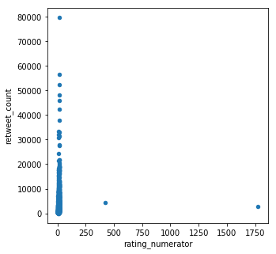

```python
copy_WeRateDogs_archive.plot(title='', x='rating_numerator', y='retweet_count' , kind='scatter', figsize=(5,5));
```

It looks like that we found couple of rating_numerators outliers .. thanks to the scatter plot.

Let's check and clean that to avoid missing our analysis.

```python
copy_WeRateDogs_archive.rating_numerator.sort_values(ascending=False).head()
```

```
802     1776.0
1795    420.0
173     14.0
65      14.0
431     14.0
Name: rating_numerator, dtype: float64
```

```python
copy_WeRateDogs_archive[(copy_WeRateDogs_archive.index == 802) | (copy_WeRateDogs_archive.index == 1795) ]
```

|  | tweet_id | in_reply_to_status_id | in_reply_to_user_id | timestamp | source | text | retweeted_status_id | retweeted_status_user_id | retweeted_status_timestamp | expanded_urls | ... | p1_conf | p1_dog | p2 | p2_conf | p2_dog | p3 | p3_conf | p3_dog | retweet_count | favorite_count |
| --- | --- | --- | --- | --- | --- | --- | --- | --- | --- | --- | --- | --- | --- | --- | --- | --- | --- | --- | --- | --- | --- |
| 802 | 749981277374128128 | NaN | NaN | 2016-07-04 15:00:45 | <a href="https://about.twitter.com/products/tweetdeck" rel="nofollow">TweetDeck</a> | This is Atticus. He's quite simply America af. 1776/10 https://t.co/GRXwMxLBkh | NaN | NaN | NaN | https://twitter.com/dog_rates/status/749981277374128128/photo/1 | ... | 0.533941 | False | sunglasses | 0.080822 | False | sunglass | 0.050776 | False | 2772 | 5569 |
| 1795 | 670842764863651840 | NaN | NaN | 2015-11-29 05:52:33 | <a href="http://twitter.com/download/iphone" rel="nofollow">Twitter for iPhone</a> | After so many requests... here you go.\n\nGood dogg. 420/10 https://t.co/yfAAo1gdeY | NaN | NaN | NaN | https://twitter.com/dog_rates/status/670842764863651840/photo/1 | ... | 0.096063 | False | accordion | 0.094075 | False | drumstick | 0.061113 | False | 4324 | 7989 |

2 rows × 31 columns

We should drop the two tweets with the unreasonable rating values.

```python
copy_WeRateDogs_archive.drop([802,1795], inplace=True)
```

```python
copy_WeRateDogs_archive.rating_numerator.sort_values(ascending=False).head()
```

```
702    14.0
117    14.0
153    14.0
152    14.0
103    14.0
Name: rating_numerator, dtype: float64
```

Now, the scatter plot points distributions is clearer.

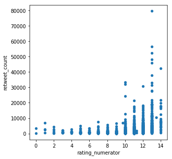

```python
copy_WeRateDogs_archive.plot(title='', x='rating_numerator', y='retweet_count' , kind='scatter', figsize=(5,5));
```

Showing counts of tweets per day of week. Useful in observing the activities volumn per day. Overall, the highest activities take place on Monday.

```python
copy_WeRateDogs_archive_filtered_columns = copy_WeRateDogs_archive[columns_of_interest]
copy_WeRateDogs_archive_filtered_columns.groupby(copy_WeRateDogs_archive_filtered_columns['timestamp'].dt.weekday_name).agg(['count'])
```

| timestamp | timestamp count | source count | rating_numerator count | rating_denominator count | name count | Dog_stage count | retweet_count count | favorite_count count |
| --- | --- | --- | --- | --- | --- | --- | --- | --- |
| Friday | 260 | 260 | 260 | 260 | 260 | 37 | 260 | 260 |
| Monday | 305 | 305 | 305 | 305 | 305 | 55 | 305 | 305 |
| Saturday | 245 | 245 | 245 | 245 | 245 | 44 | 245 | 245 |
| Sunday | 242 | 242 | 242 | 242 | 242 | 32 | 242 | 242 |
| Thursday | 272 | 272 | 272 | 272 | 272 | 48 | 272 | 272 |
| Tuesday | 275 | 275 | 275 | 275 | 275 | 52 | 275 | 275 |
| Wednesday | 279 | 279 | 279 | 279 | 279 | 46 | 279 | 279 |

The highest retweet and favorite counts are 79,515.00 and 132,810.00 respectivly.

```python
copy_WeRateDogs_archive.loc[:,['retweet_count','favorite_count']].max()
```

```
retweet_count     79515
favorite_count    132810
dtype: int64
```

```python
copy_WeRateDogs_archive.info()
```

```
<class 'pandas.core.frame.DataFrame'>
Int64Index: 1878 entries, 0 to 2072
Data columns (total 31 columns):
tweet_id                      1878 non-null int64
in_reply_to_status_id         22 non-null float64
in_reply_to_user_id           22 non-null float64
timestamp                     1878 non-null datetime64[ns]
source                        1878 non-null object
text                          1878 non-null object
retweeted_status_id           0 non-null float64
retweeted_status_user_id      0 non-null float64
retweeted_status_timestamp    0 non-null object
expanded_urls                 1878 non-null object
rating_numerator              1878 non-null float64
rating_denominator            1878 non-null float64
name                          1878 non-null object
doggo                         1878 non-null object
floofer                       1878 non-null object
pupper                        1878 non-null object
puppo                         1878 non-null object
Dog_stage                     314 non-null object
jpg_url                       1878 non-null object
img_num                       1878 non-null int64
p1                            1878 non-null object
p1_conf                       1878 non-null float64
p1_dog                        1878 non-null bool
p2                            1878 non-null object
p2_conf                       1878 non-null float64
p2_dog                        1878 non-null bool
p3                            1878 non-null object
p3_conf                       1878 non-null float64
p3_dog                        1878 non-null bool
retweet_count                 1878 non-null int64
favorite_count                1878 non-null int64
dtypes: bool(3), datetime64[ns](1), float64(9), int64(4), object(14)
memory usage: 511.0+ KB
```

We want to analyze the dog stage rating, retweet and favorite totals. As a result, we will see which dog stage is most popular and high rating across the data.

Unfortunately, we found another issue that needs to be cleaned. Upper and lower case duplicate records of Dog_Stage column. Let's correct that and unify that to lower-case.

```python
Dog_stage_columns = ['Dog_stage' , 'rating_numerator' , 'rating_denominator' , 'retweet_count' , 'favorite_count']
copy_WeRateDogs_archive_filtered_columns = copy_WeRateDogs_archive[Dog_stage_columns]
copy_WeRateDogs_archive_filtered_columns.groupby(copy_WeRateDogs_archive_filtered_columns['Dog_stage']).agg(['sum'])
```

| Dog_stage | rating_numerator sum | rating_denominator sum | retweet_count sum | favorite_count sum |
| --- | --- | --- | --- | --- |
| Doggo | 51.00 | 40.0 | 68380 | 156749 |
| PUPPER | 23.00 | 20.0 | 3789 | 9260 |
| Pupper | 60.27 | 50.0 | 14674 | 46949 |
| Puppo | 13.00 | 10.0 | 4319 | 19763 |
| doggo | 789.00 | 680.0 | 415014 | 1162562 |
| pupper | 2176.26 | 2060.0 | 476367 | 1464767 |
| puppo | 340.00 | 280.0 | 189760 | 637250 |

```python
lower_dog_stages = copy_WeRateDogs_archive.loc[:,'Dog_stage'].str.lower()
```

```python
copy_WeRateDogs_archive.loc[:,('Dog_stage')] = lower_dog_stages
```

Let's do the analysis again after fixing lower/upper dog stages issue.

```python
Dog_stage_columns = ['Dog_stage' , 'rating_numerator' , 'rating_denominator' , 'retweet_count' , 'favorite_count']
copy_WeRateDogs_archive_filtered_columns = copy_WeRateDogs_archive[Dog_stage_columns]
copy_WeRateDogs_archive_filtered_columns.groupby(copy_WeRateDogs_archive_filtered_columns['Dog_stage']).agg(['sum'])
```

| Dog_stage | rating_numerator sum | rating_denominator sum | retweet_count sum | favorite_count sum |
| --- | --- | --- | --- | --- |
| doggo | 840.00 | 720.0 | 483394 | 1319311 |
| pupper | 2259.53 | 2130.0 | 494830 | 1520976 |
| puppo | 353.00 | 290.0 | 194079 | 657013 |

The most popular dog stage is **Pupper**